# Analysis for RNA-seq and ATAC-seq data in Amiri et al 2026

###### peak up&down binomial test

```r
# Define the counts for the first group (k) and the total counts (n) for each comparison
k_values <- c(2399, 278, 1632, 484)
n_values <- c(2399 + 1703, 278 + 450, 1632 + 513, 484 + 450)
comparison_names <- c("Comp 1", "Comp 2", "Comp 3", "Comp 4")

# Create a data frame for results
results <- data.frame(
  Comparison = comparison_names,
  Count_k = k_values,
  Count_Total = n_values,
  P_value = NA,
  Proportion = k_values / n_values
)

# Run the Binomial Test for each comparison
for (i in 1:length(k_values)) {
  test_result <- binom.test(
    x = k_values[i],
    n = n_values[i],
    p = 0.5,
  )
  results$P_value[i] <- test_result$p.value
}

# Print the results
print(results)
```

```
##   Comparison Count_k Count_Total       P_value Proportion
## 1     Comp 1    2399        4102  1.476550e-27  0.5848367
## 2     Comp 2     278         728  1.931669e-10  0.3818681
## 3     Comp 3    1632        2145 3.329699e-135  0.7608392
## 4     Comp 4     484         934  2.802273e-01  0.5182013
```

```r
zld.daps.motif <- res.zld.ac.atac  %>%
  merge(x=.,y=genomic.feature.peaks, by = "peak.name",all.x = TRUE)  %>%
  merge(x=.,y=motif.table, by = "peak.name",all.x = TRUE) %>%
  #arrange(original.row) %>%
  filter(.,Sig == TRUE) %>%
  mutate(has.zld.motif = if_else((zld.sites ==TRUE | zld.sites.rc == TRUE | zld.sites.2 == TRUE | zld.sites.rc.2),TRUE,FALSE)) %>%
  group_by(., Change) %>%
  count(has.zld.motif) %>%
  mutate(percent = round((n / sum(n)) * 100,1))
```

##### Genomic distribution of Cal-zld sensitive peaks

Below is the % of DA peaks that are a particular genomic feature (exon, intron, exon-intron, promoter, or intergenic).

```r
res.zld.ac.atac %>%
  merge(x=.,y=genomic.feature.peaks, by = "peak.name",all.x = TRUE)  %>%
  merge(x=.,y=motif.table, by = "peak.name",all.x = TRUE) %>%
  #arrange(original.row) %>%
  filter(.,Sig == TRUE) %>%
  mutate(has.zld.motif = if_else((zld.sites ==TRUE | zld.sites.rc == TRUE | zld.sites.2 == TRUE | zld.sites.rc.2),TRUE,FALSE)) %>%
  count(genomic.feature) %>%
  mutate(percent = round((n / sum(n)) * 100,1)) %>%
  arrange(desc(n))
```

```
##   genomic.feature    n percent
## 1      intergenic 1622    39.5
## 2          intron 1129    27.5
## 3            exon  557    13.6
## 4 exon and intron  532    13.0
## 5        promoter  262     6.4
```

Below is the % of DA peaks that are a particular genomic feature (exon, intron, exon-intron, promoter, or intergenic) segmented by change.

```r
res.zld.ac.atac  %>%
  merge(x=.,y=genomic.feature.peaks, by = "peak.name",all.x = TRUE)  %>%
  merge(x=.,y=motif.table, by = "peak.name",all.x = TRUE) %>%
  #arrange(original.row) %>%
  filter(.,Sig == TRUE) %>%
  mutate(has.zld.motif = if_else((zld.sites ==TRUE | zld.sites.rc == TRUE | zld.sites.2 == TRUE | zld.sites.rc.2),TRUE,FALSE)) %>%
  group_by(., Change) %>%
  count(genomic.feature) %>%
  ungroup(.) %>%
  mutate(percent = round((n / sum(n)) * 100,1)) %>%
  arrange(desc(n))
```

```
## # A tibble: 10 × 4
##    Change genomic.feature     n percent
##    <chr>  <chr>           <int>   <dbl>
##  1 DOWN   intergenic       1007    24.5
##  2 DOWN   intron            662    16.1
##  3 UP     intergenic        615    15
##  4 UP     intron            467    11.4
##  5 DOWN   exon and intron   317     7.7
##  6 DOWN   exon              298     7.3
##  7 UP     exon              259     6.3
##  8 UP     exon and intron   215     5.2
##  9 UP     promoter          147     3.6
## 10 DOWN   promoter          115     2.8
```

```r
zld.daps.change.genomic.feature <- res.zld.ac.atac  %>%
  merge(x=.,y=genomic.feature.peaks, by = "peak.name",all.x = TRUE)  %>%
  merge(x=.,y=motif.table, by = "peak.name",all.x = TRUE) %>%
  #arrange(original.row) %>%
  filter(.,Sig == TRUE) %>%
  mutate(has.zld.motif = if_else((zld.sites ==TRUE | zld.sites.rc == TRUE | zld.sites.2 == TRUE | zld.sites.rc.2),TRUE,FALSE)) %>%
  group_by(., Change) %>%
  count(genomic.feature) %>%
  ungroup(.) %>%
  mutate(percent = round((n / sum(n)) * 100,1))
```

Now do the same for zldnoKD

```r
res.zldnoKD.ac.atac %>%
  merge(x=.,y=genomic.feature.peaks, by = "peak.name",all.x = TRUE)  %>%
  merge(x=.,y=motif.table, by = "peak.name",all.x = TRUE) %>%
  #arrange(original.row) %>%
  filter(.,Sig == TRUE) %>%
  mutate(has.zld.motif = if_else((zld.sites ==TRUE | zld.sites.rc == TRUE | zld.sites.2 == TRUE | zld.sites.rc.2),TRUE,FALSE)) %>%
  count(genomic.feature) %>%
  mutate(percent = round((n / sum(n)) * 100,1)) %>%
  arrange(desc(n))
```

```
##   genomic.feature   n percent
## 1      intergenic 284    39.0
## 2          intron 186    25.5
## 3            exon 120    16.5
## 4 exon and intron  79    10.9
## 5        promoter  59     8.1
```

```r
res.zldnoKD.ac.atac  %>%
  merge(x=.,y=genomic.feature.peaks, by = "peak.name",all.x = TRUE)  %>%
  merge(x=.,y=motif.table, by = "peak.name",all.x = TRUE) %>%
  #arrange(original.row) %>%
  filter(.,Sig == TRUE) %>%
  mutate(has.zld.motif = if_else((zld.sites ==TRUE | zld.sites.rc == TRUE | zld.sites.2 == TRUE | zld.sites.rc.2),TRUE,FALSE)) %>%
  group_by(., Change) %>%
  count(genomic.feature) %>%
  ungroup(.) %>%
  mutate(percent = round((n / sum(n)) * 100,1)) %>%
  arrange(desc(n))
```

```
## # A tibble: 10 × 4
##    Change genomic.feature     n percent
##    <chr>  <chr>           <int>   <dbl>
##  1 UP     intergenic        176    24.2
##  2 UP     intron            110    15.1
##  3 DOWN   intergenic        108    14.8
##  4 DOWN   intron             76    10.4
##  5 UP     exon               70     9.6
##  6 UP     exon and intron    51     7
##  7 DOWN   exon               50     6.9
##  8 UP     promoter           43     5.9
##  9 DOWN   exon and intron    28     3.8
## 10 DOWN   promoter           16     2.2
```

```r
zldnoKD.daps.change.genomic.feature <- res.zldnoKD.ac.atac  %>%
  merge(x=.,y=genomic.feature.peaks, by = "peak.name",all.x = TRUE)  %>%
  merge(x=.,y=motif.table, by = "peak.name",all.x = TRUE) %>%
  #arrange(original.row) %>%
  filter(.,Sig == TRUE) %>%
  mutate(has.zld.motif = if_else((zld.sites ==TRUE | zld.sites.rc == TRUE | zld.sites.2 == TRUE | zld.sites.rc.2),TRUE,FALSE)) %>%
  group_by(., Change) %>%
  count(genomic.feature) %>%
  ungroup(.) %>%
  mutate(percent = round((n / sum(n)) * 100,1))
```

###### Cal-zld sensitive peaks by motif and genomic feature

Below is the % of DA peaks that have a Zld motif segmented by change and genomic feature (exon, intron, exon-intron, promoter, or intergenic).

```r
All_peaks.c.gf.m <-res.zld.ac.atac %>% merge(x=.,y=genomic.feature.peaks, by = "peak.name",all.x = TRUE)  %>%
  merge(x=.,y=motif.table, by = "peak.name",all.x = TRUE) %>%
  #arrange(original.row) %>%
  mutate(has.zld.motif = if_else((zld.sites ==TRUE | zld.sites.rc == TRUE | zld.sites.2 == TRUE | zld.sites.rc.2),TRUE,FALSE)) %>%
  group_by(.,genomic.feature,Change) %>%
  count(has.zld.motif) %>%
  mutate(percent = round((n / sum(n)) * 100,1))
```

```r
pdf("../Plots/all.genomic.features.pdf", width = 2,height = 5)
All_peaks.c.gf.m  %>% group_by(genomic.feature) %>%
  summarise(
    Total_n = sum(n),
    .groups = 'drop'
  ) %>%
  mutate(DA="ALL") %>%
  mutate(percent.by.change = round((Total_n / sum(Total_n)) * 100,1)) %>%
  ggplot(data=., aes(x = DA,y = percent.by.change,fill = genomic.feature)) +
  geom_col(position = "stack") +
  #geom_text(aes(label=paste0(n," (",percent.by.change,"%)")),position = position_stack(vjust = 0.5), size = 2) +
  #scale_fill_brewer(palette="BrBG") +
  scale_fill_manual(values = c("#b5d1ae","#80ae9a","#568b87","#326b77","#1b485e")) +
  theme(axis.line = element_line(colour = "black"),
    panel.grid.major = element_blank(),
    panel.grid.minor = element_blank(),
    panel.border = element_blank(),
    panel.background = element_blank(),
     axis.text.x=element_blank(),
    axis.ticks.x=element_blank(),
     axis.title.y = element_blank(),
    legend.position = "bottom")
dev.off()
```

```r
res.zld.ac.atac %>% merge(x=.,y=genomic.feature.peaks, by = "peak.name",all.x = TRUE)  %>%
  merge(x=.,y=motif.table, by = "peak.name",all.x = TRUE) %>%
  #arrange(original.row) %>%
  filter(.,Sig == TRUE) %>%
  mutate(has.zld.motif = if_else((zld.sites ==TRUE | zld.sites.rc == TRUE | zld.sites.2 == TRUE | zld.sites.rc.2),TRUE,FALSE)) %>%
  group_by(.,genomic.feature,Change) %>%
  count(has.zld.motif) %>%
  mutate(percent = round((n / sum(n)) * 100,1))
```

```
## # A tibble: 20 × 5
## # Groups:   genomic.feature, Change [10]
##    genomic.feature Change has.zld.motif     n percent
##    <chr>           <chr>  <lgl>         <int>   <dbl>
##  1 exon            DOWN   FALSE            62    20.8
##  2 exon            DOWN   TRUE            236    79.2
##  3 exon            UP     FALSE           136    52.5
##  4 exon            UP     TRUE            123    47.5
##  5 exon and intron DOWN   FALSE            27     8.5
##  6 exon and intron DOWN   TRUE            290    91.5
##  7 exon and intron UP     FALSE            90    41.9
##  8 exon and intron UP     TRUE            125    58.1
##  9 intergenic      DOWN   FALSE           206    20.5
## 10 intergenic      DOWN   TRUE            801    79.5
## 11 intergenic      UP     FALSE           279    45.4
## 12 intergenic      UP     TRUE            336    54.6
## 13 intron          DOWN   FALSE           127    19.2
## 14 intron          DOWN   TRUE            535    80.8
## 15 intron          UP     FALSE           224    48
## 16 intron          UP     TRUE            243    52
## 17 promoter        DOWN   FALSE            25    21.7
## 18 promoter        DOWN   TRUE             90    78.3
## 19 promoter        UP     FALSE            69    46.9
## 20 promoter        UP     TRUE             78    53.1
```

```r
zld.ac.daps.c.gf.m <- res.zld.ac.atac %>%
  merge(x=.,y=genomic.feature.peaks, by = "peak.name",all.x = TRUE)  %>%
  merge(x=.,y=motif.table, by = "peak.name",all.x = TRUE) %>%
  #arrange(original.row) %>%
  filter(.,Sig == TRUE) %>%
  mutate(has.zld.motif = if_else((zld.sites ==TRUE | zld.sites.rc == TRUE | zld.sites.2 == TRUE | zld.sites.rc.2),TRUE,FALSE)) %>%
  group_by(.,genomic.feature,Change) %>%
  count(has.zld.motif) %>%
  mutate(percent = round((n / sum(n)) * 100,1))
```

```r
pdf("../Plots/zldvsAC.genomic.features.pdf", width = 2,height = 5)
zld.ac.daps.c.gf.m  %>% group_by(genomic.feature) %>%
  summarise(
    Total_n = sum(n),
    .groups = 'drop'
  ) %>%
  mutate(DA="WTvsAC") %>%
  mutate(percent.by.change = round((Total_n / sum(Total_n)) * 100,1)) %>%
  ggplot(data=., aes(x = DA,y = percent.by.change,fill = genomic.feature)) +
  geom_col(position = "stack") +
  #geom_text(aes(label=paste0(n," (",percent.by.change,"%)")),position = position_stack(vjust = 0.5), size = 2) +
  #scale_fill_brewer(palette="BrBG") +
  scale_fill_manual(values = c("#b5d1ae","#80ae9a","#568b87","#326b77","#1b485e")) +
  theme(axis.line = element_line(colour = "black"),
    panel.grid.major = element_blank(),
    panel.grid.minor = element_blank(),
    panel.border = element_blank(),
    panel.background = element_blank(),
     axis.text.x=element_blank(),
    axis.ticks.x=element_blank(),
     axis.title.y = element_blank(),
    legend.position = "bottom")
dev.off()
```

```r
pdf("../Plots/zldvsAC.up.genomic.features.pdf", width = 2,height = 5)
zld.ac.daps.c.gf.m  %>%filter(Change == "UP")%>% group_by(genomic.feature) %>%
  summarise(
    Total_n = sum(n),
    .groups = 'drop'
  ) %>%
  mutate(DA="WTvsAC") %>%
  mutate(percent.by.change = round((Total_n / sum(Total_n)) * 100,1)) %>%
  ggplot(data=., aes(x = DA,y = percent.by.change,fill = genomic.feature)) +
  geom_col(position = "stack") +
  #geom_text(aes(label=paste0(n," (",percent.by.change,"%)")),position = position_stack(vjust = 0.5), size = 2) +
  #scale_fill_brewer(palette="BrBG") +
  scale_fill_manual(values = c("#b5d1ae","#80ae9a","#568b87","#326b77","#1b485e")) +
  theme(axis.line = element_line(colour = "black"),
    panel.grid.major = element_blank(),
    panel.grid.minor = element_blank(),
    panel.border = element_blank(),
    panel.background = element_blank(),
     axis.text.x=element_blank(),
    axis.ticks.x=element_blank(),
     axis.title.y = element_blank(),
    legend.position = "bottom")
dev.off()
```

```r
pdf("../Plots/zldvsAC.down.genomic.features.pdf", width = 2,height = 5)
zld.ac.daps.c.gf.m  %>%filter(Change == "DOWN")%>% group_by(genomic.feature) %>%
  summarise(
    Total_n = sum(n),
    .groups = 'drop'
  ) %>%
  mutate(DA="WTvsAC") %>%
  mutate(percent.by.change = round((Total_n / sum(Total_n)) * 100,1)) %>%
  ggplot(data=., aes(x = DA,y = percent.by.change,fill = genomic.feature)) +
  geom_col(position = "stack") +
  #geom_text(aes(label=paste0(n," (",percent.by.change,"%)")),position = position_stack(vjust = 0.5), size = 2) +
  #scale_fill_brewer(palette="BrBG") +
  scale_fill_manual(values = c("#b5d1ae","#80ae9a","#568b87","#326b77","#1b485e")) +
  theme(axis.line = element_line(colour = "black"),
    panel.grid.major = element_blank(),
    panel.grid.minor = element_blank(),
    panel.border = element_blank(),
    panel.background = element_blank(),
     axis.text.x=element_blank(),
    axis.ticks.x=element_blank(),
     axis.title.y = element_blank(),
    legend.position = "bottom")
dev.off()
```

```r
res.zldnoKD.ac.atac %>% merge(x=.,y=genomic.feature.peaks, by = "peak.name",all.x = TRUE)  %>%
  merge(x=.,y=motif.table, by = "peak.name",all.x = TRUE) %>%
  #arrange(original.row) %>%
  filter(.,Sig == TRUE) %>%
  mutate(has.zld.motif = if_else((zld.sites ==TRUE | zld.sites.rc == TRUE | zld.sites.2 == TRUE | zld.sites.rc.2),TRUE,FALSE)) %>%
  group_by(.,genomic.feature,Change) %>%
  count(has.zld.motif) %>%
  mutate(percent = round((n / sum(n)) * 100,1))
```

```
## # A tibble: 20 × 5
## # Groups:   genomic.feature, Change [10]
##    genomic.feature Change has.zld.motif     n percent
##    <chr>           <chr>  <lgl>         <int>   <dbl>
##  1 exon            DOWN   FALSE            23    46
##  2 exon            DOWN   TRUE             27    54
##  3 exon            UP     FALSE            22    31.4
##  4 exon            UP     TRUE             48    68.6
##  5 exon and intron DOWN   FALSE             8    28.6
##  6 exon and intron DOWN   TRUE             20    71.4
##  7 exon and intron UP     FALSE            12    23.5
##  8 exon and intron UP     TRUE             39    76.5
##  9 intergenic      DOWN   FALSE            55    50.9
## 10 intergenic      DOWN   TRUE             53    49.1
## 11 intergenic      UP     FALSE            47    26.7
## 12 intergenic      UP     TRUE            129    73.3
## 13 intron          DOWN   FALSE            40    52.6
## 14 intron          DOWN   TRUE             36    47.4
## 15 intron          UP     FALSE            32    29.1
## 16 intron          UP     TRUE             78    70.9
## 17 promoter        DOWN   FALSE             6    37.5
## 18 promoter        DOWN   TRUE             10    62.5
## 19 promoter        UP     FALSE            15    34.9
## 20 promoter        UP     TRUE             28    65.1
```

```r
zldnoKD.ac.daps.c.gf.m <- res.zldnoKD.ac.atac %>%
  merge(x=.,y=genomic.feature.peaks, by = "peak.name",all.x = TRUE)  %>%
  merge(x=.,y=motif.table, by = "peak.name",all.x = TRUE) %>%
  #arrange(original.row) %>%
  filter(.,Sig == TRUE) %>%
  mutate(has.zld.motif = if_else((zld.sites ==TRUE | zld.sites.rc == TRUE | zld.sites.2 == TRUE | zld.sites.rc.2),TRUE,FALSE)) %>%
  group_by(.,genomic.feature,Change) %>%
  count(has.zld.motif) %>%
  mutate(percent = round((n / sum(n)) * 100,1))
```

```r
pdf("../Plots/zldnoKDvsAC.genomic.features.pdf", width = 2,height = 5)
zldnoKD.ac.daps.c.gf.m  %>% group_by(genomic.feature) %>%
  summarise(
    Total_n = sum(n),
    .groups = 'drop'
  ) %>%
  mutate(DA="WTvsAC") %>%
  mutate(percent.by.change = round((Total_n / sum(Total_n)) * 100,1)) %>%
  ggplot(data=., aes(x = DA,y = percent.by.change,fill = genomic.feature)) +
  geom_col(position = "stack") +
  #geom_text(aes(label=paste0(n," (",percent.by.change,"%)")),position = position_stack(vjust = 0.5), size = 2) +
  #scale_fill_brewer(palette="BrBG") +
  scale_fill_manual(values = c("#b5d1ae","#80ae9a","#568b87","#326b77","#1b485e")) +
  theme(axis.line = element_line(colour = "black"),
    panel.grid.major = element_blank(),
    panel.grid.minor = element_blank(),
    panel.border = element_blank(),
    panel.background = element_blank(),
     axis.text.x=element_blank(),
    axis.ticks.x=element_blank(),
     axis.title.y = element_blank(),
    legend.position = "bottom")
dev.off()
```

```r
pdf("../Plots/zldnoKDvsAC.genomic.up.features.pdf", width = 2,height = 5)
zldnoKD.ac.daps.c.gf.m  %>% filter(Change=="UP") %>% group_by(genomic.feature) %>%
  summarise(
    Total_n = sum(n),
    .groups = 'drop'
  ) %>%
  mutate(DA="WTvsAC") %>%
  mutate(percent.by.change = round((Total_n / sum(Total_n)) * 100,1)) %>%
  ggplot(data=., aes(x = DA,y = percent.by.change,fill = genomic.feature)) +
  geom_col(position = "stack") +
  #geom_text(aes(label=paste0(n," (",percent.by.change,"%)")),position = position_stack(vjust = 0.5), size = 2) +
  #scale_fill_brewer(palette="BrBG") +
  scale_fill_manual(values = c("#b5d1ae","#80ae9a","#568b87","#326b77","#1b485e")) +
  theme(axis.line = element_line(colour = "black"),
    panel.grid.major = element_blank(),
    panel.grid.minor = element_blank(),
    panel.border = element_blank(),
    panel.background = element_blank(),
     axis.text.x=element_blank(),
    axis.ticks.x=element_blank(),
     axis.title.y = element_blank(),
    legend.position = "bottom")
dev.off()
```

```r
pdf("../Plots/zldnoKDvsAC.genomic.down.features.pdf", width = 2,height = 5)
zldnoKD.ac.daps.c.gf.m  %>% filter(Change=="DOWN") %>% group_by(genomic.feature) %>%
  summarise(
    Total_n = sum(n),
    .groups = 'drop'
  ) %>%
  mutate(DA="WTvsAC") %>%
  mutate(percent.by.change = round((Total_n / sum(Total_n)) * 100,1)) %>%
  ggplot(data=., aes(x = DA,y = percent.by.change,fill = genomic.feature)) +
  geom_col(position = "stack") +
  #geom_text(aes(label=paste0(n," (",percent.by.change,"%)")),position = position_stack(vjust = 0.5), size = 2) +
  #scale_fill_brewer(palette="BrBG") +
  scale_fill_manual(values = c("#b5d1ae","#80ae9a","#568b87","#326b77","#1b485e")) +
  theme(axis.line = element_line(colour = "black"),
    panel.grid.major = element_blank(),
    panel.grid.minor = element_blank(),
    panel.border = element_blank(),
    panel.background = element_blank(),
     axis.text.x=element_blank(),
    axis.ticks.x=element_blank(),
     axis.title.y = element_blank(),
    legend.position = "bottom")
dev.off()
```

```r
zld.zldnoKD.daps.c.gf.m <- res.zld.noKD.atac %>%
  merge(x=.,y=genomic.feature.peaks, by = "peak.name",all.x = TRUE)  %>%
  merge(x=.,y=motif.table, by = "peak.name",all.x = TRUE) %>%
  #arrange(original.row) %>%
  filter(.,Sig == TRUE) %>%
  mutate(has.zld.motif = if_else((zld.sites ==TRUE | zld.sites.rc == TRUE | zld.sites.2 == TRUE | zld.sites.rc.2),TRUE,FALSE)) %>%
  group_by(.,genomic.feature,Change) %>%
  count(has.zld.motif) %>%
  mutate(percent = round((n / sum(n)) * 100,1))
```

```r
pdf("../Plots/zldvszldnoKD.genomic.features.pdf", width = 2,height = 5)
zld.zldnoKD.daps.c.gf.m  %>% group_by(genomic.feature) %>%
  summarise(
    Total_n = sum(n),
    .groups = 'drop'
  ) %>%
  mutate(DA="WTvsAC") %>%
  mutate(percent.by.change = round((Total_n / sum(Total_n)) * 100,1)) %>%
  ggplot(data=., aes(x = DA,y = percent.by.change,fill = genomic.feature)) +
  geom_col(position = "stack") +
  #geom_text(aes(label=paste0(n," (",percent.by.change,"%)")),position = position_stack(vjust = 0.5), size = 2) +
  #scale_fill_brewer(palette="BrBG") +
  scale_fill_manual(values = c("#b5d1ae","#80ae9a","#568b87","#326b77","#1b485e")) +
  theme(axis.line = element_line(colour = "black"),
    panel.grid.major = element_blank(),
    panel.grid.minor = element_blank(),
    panel.border = element_blank(),
    panel.background = element_blank(),
     axis.text.x=element_blank(),
    axis.ticks.x=element_blank(),
     axis.title.y = element_blank(),
    legend.position = "bottom")
dev.off()
```

```r
pdf("../Plots/zldvszldnoKD.up.genomic.features.pdf", width = 2,height = 5)
zld.zldnoKD.daps.c.gf.m  %>%filter(Change=="UP") %>% group_by(genomic.feature) %>%
  summarise(
    Total_n = sum(n),
    .groups = 'drop'
  ) %>%
  mutate(DA="zldvszldnoKD") %>%
  mutate(percent.by.change = round((Total_n / sum(Total_n)) * 100,1)) %>%
  ggplot(data=., aes(x = DA,y = percent.by.change,fill = genomic.feature)) +
  geom_col(position = "stack") +
  #geom_text(aes(label=paste0(n," (",percent.by.change,"%)")),position = position_stack(vjust = 0.5), size = 2) +
  #scale_fill_brewer(palette="BrBG") +
  scale_fill_manual(values = c("#b5d1ae","#80ae9a","#568b87","#326b77","#1b485e")) +
  theme(axis.line = element_line(colour = "black"),
    panel.grid.major = element_blank(),
    panel.grid.minor = element_blank(),
    panel.border = element_blank(),
    panel.background = element_blank(),
     axis.text.x=element_blank(),
    axis.ticks.x=element_blank(),
     axis.title.y = element_blank(),
    legend.position = "bottom")
dev.off()
```

```r
pdf("../Plots/zldvszldnoKD.down.genomic.features.pdf", width = 2,height = 5)
zld.zldnoKD.daps.c.gf.m  %>%filter(Change=="DOWN") %>% group_by(genomic.feature) %>%
  summarise(
    Total_n = sum(n),
    .groups = 'drop'
  ) %>%
  mutate(DA="zldvszldnoKD") %>%
  mutate(percent.by.change = round((Total_n / sum(Total_n)) * 100,1)) %>%
  ggplot(data=., aes(x = DA,y = percent.by.change,fill = genomic.feature)) +
  geom_col(position = "stack") +
  #geom_text(aes(label=paste0(n," (",percent.by.change,"%)")),position = position_stack(vjust = 0.5), size = 2) +
  #scale_fill_brewer(palette="BrBG") +
  scale_fill_manual(values = c("#b5d1ae","#80ae9a","#568b87","#326b77","#1b485e")) +
  theme(axis.line = element_line(colour = "black"),
    panel.grid.major = element_blank(),
    panel.grid.minor = element_blank(),
    panel.border = element_blank(),
    panel.background = element_blank(),
     axis.text.x=element_blank(),
    axis.ticks.x=element_blank(),
     axis.title.y = element_blank(),
    legend.position = "bottom")
dev.off()
```

```r
df_list <- list(All=All_peaks.c.gf.m, zldvsAC =zld.ac.daps.c.gf.m, zldvszldnoKD = zld.zldnoKD.daps.c.gf.m, zldnoKDvsAC=zldnoKD.ac.daps.c.gf.m)
df_list_down<-lapply(df_list, function(x){filter(x, Change == "DOWN")})
df_list_up<-lapply(df_list, function(x){filter(x, Change == "UP")})
# 2. Calculate percentages and merge
Genomic_features_summary<- df_list %>%
  imap(function(df, name) {
    df %>%
      group_by(genomic.feature) %>%
      summarise(count = sum(n), .groups = "drop") %>%
      mutate(!!paste0(name, "_Percent") := count / sum(count) * 100) %>%
      select(-count) # Keep only feature and calculated percent
  }) %>%
  reduce(full_join, by = "genomic.feature")
Genomic_features_summary_down<- df_list_down %>%
  imap(function(df, name) {
    df %>%
      group_by(genomic.feature) %>%
      summarise(count = sum(n), .groups = "drop") %>%
      mutate(!!paste0(name, "_Percent") := count / sum(count) * 100) %>%
      select(-count) # Keep only feature and calculated percent
  }) %>%
  reduce(full_join, by = "genomic.feature")

Genomic_features_summary_up<- df_list_up %>%
  imap(function(df, name) {
    df %>%
      group_by(genomic.feature) %>%
      summarise(count = sum(n), .groups = "drop") %>%
      mutate(!!paste0(name, "_Percent") := count / sum(count) * 100) %>%
      select(-count) # Keep only feature and calculated percent
  }) %>%
  reduce(full_join, by = "genomic.feature")
write.csv(Genomic_features_summary, "../zldKD/zldKD_Genomic_features_summary.csv")
write.csv(Genomic_features_summary_down, "../zldKD/Genomic_features_summary_down.csv")
write.csv(Genomic_features_summary_up, "../zldKD/Genomic_features_summary_up.csv")
```

###### Cal-zld sensitive peaks and dynamic peaks

Below is the % of DA peaks that fall into a dynamic/non dynamic group segmented by change.

```r
res.zld.ac.atac %>%
merge(x=.,y=genomic.feature.peaks, by = "peak.name",all.x = TRUE)  %>%
  merge(x=.,y=motif.table, by = "peak.name",all.x = TRUE) %>%
  #merge(x=.,y=peaks.open.by.stage, by = "peak.name",all.x = TRUE) %>%
  merge(x=.,y=patterns.group.table, by = "peak.name",all.x = TRUE) %>%
  #arrange(original.row) %>%
  mutate(has.zld.motif = if_else((zld.sites ==TRUE | zld.sites.rc == TRUE | zld.sites.2 == TRUE | zld.sites.rc.2),TRUE,FALSE)) %>%
  mutate(Change = case_when(
  Change == "UP" ~ "UP",
  Change == "DOWN" ~ "DOWN",
  Change == "NA" ~ "Not affected")) %>%
  mutate(class = case_when(
  group.1 == TRUE ~ "group.1",
  group.2 == TRUE ~ "group.2",
  group.3 == TRUE ~ "group.3",
  group.4 == TRUE ~ "group.4",
  group.5 == TRUE ~ "group.5",
  group.6 == TRUE ~ "group.6",
  group.7 == TRUE ~ "group.7",
  group.8 == TRUE ~ "group.8",
  group.9 == TRUE ~ "group.9",
  group.10 == TRUE ~ "group.10",
  group.11 == TRUE ~ "group.11",
  group.12 == TRUE ~ "group.12",
  group.13 == TRUE ~ "group.13",
  group.14 == TRUE ~ "group.14",
  group.15 == TRUE ~ "group.15",
  group.16 == TRUE ~ "group.16",
  group.17 == TRUE ~ "group.17",
  group.18 == TRUE ~ "group.18",
  group.19 == TRUE ~ "group.19",
  group.20 == TRUE ~ "group.20",
  group.21 == TRUE ~ "group.21",
  dynamic.peak == TRUE & dynamic.in.class == FALSE ~ "dynamic not in group",
  dynamic.peak == FALSE & dynamic.in.class == FALSE ~ "not dynamic not in group")) %>%
  filter(., Sig == TRUE) %>%
  group_by(., Change) %>%
  count(class) %>%
  ungroup(.) %>%
  mutate(percent = round((n / sum(n)) * 100,2)) %>%
  arrange(desc(n)) %>% group_split(Change)
```

```
## <list_of<
##   tbl_df<
##     Change : character
##     class  : character
##     n      : integer
##     percent: double
##   >
## >[2]>
## [[1]]
## # A tibble: 18 × 4
##    Change class                        n percent
##    <chr>  <chr>                    <int>   <dbl>
##  1 DOWN   not dynamic not in group  1533   37.4
##  2 DOWN   group.8                    381    9.29
##  3 DOWN   group.15                   186    4.53
##  4 DOWN   group.14                    64    1.56
##  5 DOWN   group.12                    55    1.34
##  6 DOWN   group.6                     35    0.85
##  7 DOWN   group.10                    23    0.56
##  8 DOWN   group.1                     22    0.54
##  9 DOWN   group.5                     20    0.49
## 10 DOWN   group.4                     19    0.46
## 11 DOWN   group.9                     19    0.46
## 12 DOWN   group.7                     11    0.27
## 13 DOWN   group.11                     8    0.2
## 14 DOWN   group.16                     8    0.2
## 15 DOWN   group.13                     6    0.15
## 16 DOWN   group.19                     4    0.1
## 17 DOWN   group.21                     4    0.1
## 18 DOWN   group.20                     1    0.02
##
## [[2]]
## # A tibble: 17 × 4
##    Change class                        n percent
##    <chr>  <chr>                    <int>   <dbl>
##  1 UP     not dynamic not in group  1096   26.7
##  2 UP     group.1                    235    5.73
##  3 UP     group.5                    178    4.34
##  4 UP     group.3                     72    1.76
##  5 UP     group.13                    35    0.85
##  6 UP     group.7                     29    0.71
##  7 UP     group.6                     16    0.39
##  8 UP     group.18                    12    0.29
##  9 UP     group.4                     11    0.27
## 10 UP     group.15                     5    0.12
## 11 UP     group.9                      5    0.12
## 12 UP     group.10                     3    0.07
## 13 UP     group.12                     2    0.05
## 14 UP     group.11                     1    0.02
## 15 UP     group.14                     1    0.02
## 16 UP     group.2                      1    0.02
## 17 UP     group.20                     1    0.02
```

Write to a df.

```r
zld.ac.daps.dynamic.peaks <- res.zld.ac.atac %>%
merge(x=.,y=genomic.feature.peaks, by = "peak.name",all.x = TRUE)  %>%
  merge(x=.,y=motif.table, by = "peak.name",all.x = TRUE) %>%
  #merge(x=.,y=peaks.open.by.stage, by = "peak.name",all.x = TRUE) %>%
  merge(x=.,y=patterns.group.table, by = "peak.name",all.x = TRUE) %>%
  #arrange(original.row) %>%
  mutate(has.zld.motif = if_else((zld.sites ==TRUE | zld.sites.rc == TRUE | zld.sites.2 == TRUE | zld.sites.rc.2),TRUE,FALSE)) %>%
  mutate(Change = case_when(
  Change == "UP" ~ "UP",
  Change == "DOWN" ~ "DOWN",
  Change == "NA" ~ "Not affected")) %>%
  mutate(class = case_when(
  group.1 == TRUE ~ "group.1",
  group.2 == TRUE ~ "group.2",
  group.3 == TRUE ~ "group.3",
  group.4 == TRUE ~ "group.4",
  group.5 == TRUE ~ "group.5",
  group.6 == TRUE ~ "group.6",
  group.7 == TRUE ~ "group.7",
  group.8 == TRUE ~ "group.8",
  group.9 == TRUE ~ "group.9",
  group.10 == TRUE ~ "group.10",
  group.11 == TRUE ~ "group.11",
  group.12 == TRUE ~ "group.12",
  group.13 == TRUE ~ "group.13",
  group.14 == TRUE ~ "group.14",
  group.15 == TRUE ~ "group.15",
  group.16 == TRUE ~ "group.16",
  group.17 == TRUE ~ "group.17",
  group.18 == TRUE ~ "group.18",
  group.19 == TRUE ~ "group.19",
  group.20 == TRUE ~ "group.20",
  group.21 == TRUE ~ "group.21",
  dynamic.peak == TRUE & dynamic.in.class == FALSE ~ "dynamic not in group",
  dynamic.peak == FALSE & dynamic.in.class == FALSE ~ "not dynamic not in group")) %>%
  filter(., Sig == TRUE) %>%
  group_by(., Change) %>%
  count(class) %>%
  ungroup(.) %>%
  mutate(percent = round((n / sum(n)) * 100,2))
```

##### Cal-zld sensitive peaks and dynamic peaks

From the above we observe that peaks that gain or lose accessibility upon Cal-zld KD are in different dynamic classes. Notably peaks that gain accessibility upon Cal-zld depletion are in groups of peaks who lose accessibility as nuclear cycles progress. Conversely peaks that lose accessibility upon Cal-zld KD are peaks that gain accessibility as nuclear cycles progress. See (Dynamic groups plot , patterns$plot)

We will test if membership in any dynamic group selects for Cal-zld sensitivity (gain or loss of accessibility) more frequently than we would expect from random chance. This will be done by using R functions to perform uses the odds ratio and fishers test on basic contingency tables denoting presence/absence in a dynamic group and Cal-zld sensitivity/insensitivity.

First we will reorganize the data

We will use the table with the dynamic/non dynamic classification of peaks.

```r
patterns.group.table<-read.delim("../WT_timecourse/patterns-group-table.txt")
head(patterns.group.table)
```

```
##                  peak.name group.1 group.2 group.3 group.4 group.5 group.6
## 1   scaffold_1:39064-39403   FALSE   FALSE   FALSE   FALSE   FALSE   FALSE
## 2   scaffold_1:41080-41159   FALSE   FALSE   FALSE   FALSE   FALSE   FALSE
## 3   scaffold_1:46323-46446   FALSE   FALSE   FALSE   FALSE   FALSE   FALSE
## 4 scaffold_1:113573-113903   FALSE   FALSE   FALSE   FALSE   FALSE   FALSE
## 5 scaffold_1:114565-114639   FALSE   FALSE   FALSE   FALSE   FALSE   FALSE
## 6 scaffold_1:116022-116187   FALSE   FALSE   FALSE   FALSE   FALSE   FALSE
##   group.7 group.8 group.9 group.10 group.11 group.12 group.13 group.14 group.15
## 1   FALSE   FALSE   FALSE    FALSE    FALSE    FALSE    FALSE    FALSE    FALSE
## 2   FALSE   FALSE   FALSE    FALSE    FALSE    FALSE    FALSE    FALSE    FALSE
## 3   FALSE   FALSE   FALSE    FALSE    FALSE    FALSE    FALSE    FALSE    FALSE
## 4   FALSE   FALSE   FALSE    FALSE    FALSE    FALSE    FALSE    FALSE    FALSE
## 5   FALSE   FALSE   FALSE    FALSE    FALSE    FALSE    FALSE    FALSE    FALSE
## 6   FALSE   FALSE   FALSE    FALSE    FALSE    FALSE    FALSE    FALSE    FALSE
##   group.16 group.17 group.18 group.19 group.20 group.21 dynamic.peak
## 1    FALSE    FALSE    FALSE    FALSE    FALSE    FALSE        FALSE
## 2    FALSE    FALSE    FALSE    FALSE    FALSE    FALSE        FALSE
## 3    FALSE    FALSE    FALSE    FALSE    FALSE    FALSE        FALSE
## 4    FALSE    FALSE    FALSE    FALSE    FALSE    FALSE        FALSE
## 5    FALSE    FALSE    FALSE    FALSE    FALSE    FALSE        FALSE
## 6    FALSE    FALSE    FALSE    FALSE    FALSE    FALSE        FALSE
##   non.dynamic.peak dynamic.in.class
## 1             TRUE            FALSE
## 2             TRUE            FALSE
## 3             TRUE            FALSE
## 4             TRUE            FALSE
## 5             TRUE            FALSE
## 6             TRUE            FALSE
```

Now we will create a new table “zld.daps.dynamics”. This table contains the name of the peak “peak.name”, a column “Change.in.zld” denoting if a the change in accessibility was UP or DOWN and a column “class” denoting the peak’s dynamic group or non dynamic classification.

Note: not all of the mater peaks were included in the Cal-zld DE analysis, recall that peaks with low count values are removed before DESeq2 analysis.

```r
zld.daps.dynamics <- res.zld.ac.atac %>%
  merge(x=.,y=patterns.group.table, by = "peak.name",all.x = TRUE) %>%
  mutate(class = case_when(
  group.1 == TRUE ~ "group.1",
  group.2 == TRUE ~ "group.2",
  group.3 == TRUE ~ "group.3",
  group.4 == TRUE ~ "group.4",
  group.5 == TRUE ~ "group.5",
  group.6 == TRUE ~ "group.6",
  group.7 == TRUE ~ "group.7",
  group.8 == TRUE ~ "group.8",
  group.9 == TRUE ~ "group.9",
  group.10 == TRUE ~ "group.10",
  group.11 == TRUE ~ "group.11",
  group.12 == TRUE ~ "group.12",
  group.13 == TRUE ~ "group.13",
  group.14 == TRUE ~ "group.14",
  group.15 == TRUE ~ "group.15",
  group.16 == TRUE ~ "group.16",
  group.17 == TRUE ~ "group.17",
  group.18 == TRUE ~ "group.18",
  group.19 == TRUE ~ "group.19",
  group.20 == TRUE ~ "group.20",
  group.21 == TRUE ~ "group.21",
  dynamic.peak == TRUE & dynamic.in.class == FALSE ~ "dynamic not in group",
  dynamic.peak == FALSE & dynamic.in.class == FALSE ~ "not dynamic not in group")) %>%
   mutate(.,Change.in.zld = case_when(Sig == TRUE & Change == "UP" ~ "UP",
                                     Sig == TRUE & Change == "DOWN" ~ "DOWN",
                                     is.na(Sig) & Change == "DOWN" ~ "NA",
                                     is.na(Sig) & Change == "UP" ~ "NA")) %>%
  mutate(Change.in.zld = if_else(is.na(Change.in.zld),"Not affected",Change.in.zld)) %>%
  mutate(Change.in.zld = if_else(Change.in.zld == "NA","Not affected",Change.in.zld)) %>% select(c(peak.name,Change.in.zld,class))

head(zld.daps.dynamics)
```

```
##                      peak.name Change.in.zld                    class
## 1 scaffold_1:10000463-10000657  Not affected not dynamic not in group
## 2 scaffold_1:10060972-10061057  Not affected not dynamic not in group
## 3 scaffold_1:10061819-10061927  Not affected                  group.3
## 4 scaffold_1:10063872-10063984  Not affected not dynamic not in group
## 5 scaffold_1:10064176-10064346  Not affected                  group.3
## 6 scaffold_1:10064610-10065033  Not affected not dynamic not in group
```

We will use the “zld.daps.dynamics” to perform the odds ratio and fisher test.

Each group Cal-zld sensitive DOWN, Cal-zld sensitive UP and Not affect will be tested separately.

First Cal-zld sensitive DOWN.

Below constructs the contingency table, performs the odds ratio and fisher test for each dynamic/non-dynamic group. The output is a long list, which in following chunks will be turned into a dataframe.

```r
groupnames = unique(zld.daps.dynamics$class)

fisher.down = sapply(groupnames, function(x) {
  contingency = matrix(c(
    "down_inclass" = sum(zld.daps.dynamics$Change.in.zld == "DOWN" & zld.daps.dynamics$class == x),
    "down_!inclass" = sum(zld.daps.dynamics$Change.in.zld == "DOWN" & !zld.daps.dynamics$class == x),
    "!down_inclass" = sum(!zld.daps.dynamics$Change.in.zld == "DOWN" & zld.daps.dynamics$class == x),
    "!down_!inclass" = sum(!zld.daps.dynamics$Change.in.zld == "DOWN" & !zld.daps.dynamics$class == x)
  ),
  nrow = 2,
  byrow = TRUE
  )

  f = fisher.test(contingency)
  return(list(pval = f$p.value, log2odds = log2(f$estimate), table = contingency))
}, simplify = FALSE)

head(fisher.down)
```

```
## $`not dynamic not in group`
## $`not dynamic not in group`$pval
## [1] 2.302188e-65
##
## $`not dynamic not in group`$log2odds
## odds ratio
##  -1.160626
##
## $`not dynamic not in group`$table
##       [,1] [,2]
## [1,]  1533  866
## [2,] 19186 4848
##
##
## $group.3
## $group.3$pval
## [1] 6.756913e-37
##
## $group.3$log2odds
## odds ratio
##       -Inf
##
## $group.3$table
##      [,1]  [,2]
## [1,]    0  2399
## [2,]  867 23167
##
##
## $group.1
## $group.1$pval
## [1] 2.669245e-12
##
## $group.1$log2odds
## odds ratio
##  -1.812984
##
## $group.1$table
##      [,1]  [,2]
## [1,]   22  2377
## [2,]  757 23277
```

[output cut: 27 more lines]

```
## [2,]  219 23815
##
##
## $group.15
## $group.15$pval
## [1] 1.332711e-55
##
## $group.15$log2odds
## odds ratio
##   2.322981
##
## $group.15$table
##      [,1]  [,2]
## [1,]  186  2213
## [2,]  397 23637
```

Lets make this a df so that it is easier to work with.

```r
fisher.down.df <- lapply(fisher.down, function(x){unlist(x[1:3])})
fisher.down.df <- do.call("rbind",fisher.down.df)

fisher.down.df <- as.data.frame(fisher.down.df)

head(fisher.down.df)
```

```
##                                   pval log2odds.odds ratio table1 table2 table3
## not dynamic not in group  2.302188e-65           -1.160626   1533  19186    866
## group.3                   6.756913e-37                -Inf      0    867   2399
## group.1                   2.669245e-12           -1.812984     22    757   2377
## group.8                  3.360947e-176            3.267753    381    462   2018
## group.14                  7.237835e-12            1.575398     64    219   2335
## group.15                  1.332711e-55            2.322981    186    397   2213
##                          table4
## not dynamic not in group   4848
## group.3                   23167
## group.1                   23277
## group.8                   23572
## group.14                  23815
## group.15                  23637
```

Now will add the class column, and fix the column names.

```r
fisher.down.df <- fisher.down.df %>%
  mutate(class = rownames(.)) %>%
  relocate(class,.before = pval) %>%
  rename("pval.fish.down" = pval,
         "log2odds.odds.ratio.fish.down" = `log2odds.odds ratio`,
         "YY.fish.down" = table1,
         "NY.fish.down" = table2,
         "YN.fish.down" = table3,
         "NN.fish.down" = table4)


head(fisher.down.df)
```

```
##                                             class pval.fish.down
## not dynamic not in group not dynamic not in group   2.302188e-65
## group.3                                   group.3   6.756913e-37
## group.1                                   group.1   2.669245e-12
## group.8                                   group.8  3.360947e-176
## group.14                                 group.14   7.237835e-12
## group.15                                 group.15   1.332711e-55
##                          log2odds.odds.ratio.fish.down YY.fish.down
## not dynamic not in group                     -1.160626         1533
## group.3                                           -Inf            0
## group.1                                      -1.812984           22
## group.8                                       3.267753          381
## group.14                                      1.575398           64
## group.15                                      2.322981          186
##                          NY.fish.down YN.fish.down NN.fish.down
## not dynamic not in group        19186          866         4848
## group.3                           867         2399        23167
## group.1                           757         2377        23277
## group.8                           462         2018        23572
## group.14                          219         2335        23815
## group.15                          397         2213        23637
```

These groups are likely to be dynamic peak groups whose accessibility is Cal-zld dependent. We will select for groups that have a log2(odd ratio) greater than 1.5.

```r
fisher.down.df %>% filter(log2odds.odds.ratio.fish.down > 1.5)
```

```
##             class pval.fish.down log2odds.odds.ratio.fish.down YY.fish.down
## group.8   group.8  3.360947e-176                      3.267753          381
## group.14 group.14   7.237835e-12                      1.575398           64
## group.15 group.15   1.332711e-55                      2.322981          186
## group.12 group.12   4.635497e-12                      1.736848           55
## group.16 group.16   8.654635e-05                      3.006628            8
##          NY.fish.down YN.fish.down NN.fish.down
## group.8           462         2018        23572
## group.14          219         2335        23815
## group.15          397         2213        23637
## group.12          168         2344        23866
## group.16           10         2391        24024
```

Cal-zld sensitive UP.

```r
fisher.up = sapply(groupnames, function(x) {
  contingency = matrix(c(
    "up_inclass" = sum(zld.daps.dynamics$Change.in.zld == "UP" & zld.daps.dynamics$class == x),
    "up_!inclass" = sum(zld.daps.dynamics$Change.in.zld == "UP" & !zld.daps.dynamics$class == x),
    "!up_inclass" = sum(!zld.daps.dynamics$Change.in.zld == "UP" & zld.daps.dynamics$class == x),
    "!up_!inclass" = sum(!zld.daps.dynamics$Change.in.zld == "UP" & !zld.daps.dynamics$class == x)
  ),
  nrow = 2,
  byrow = TRUE
  )

  f = fisher.test(contingency)
  return(list(pval = f$p.value, log2odds = log2(f$estimate), table = contingency))
}, simplify = FALSE)

#fisher.up
```

Lets make this a df so that it is easier to work with.

```r
fisher.up.df <- lapply(fisher.up, function(x){unlist(x[1:3])})
fisher.up.df <- do.call("rbind",fisher.up.df)

fisher.up.df <- as.data.frame(fisher.up.df)

head(fisher.up.df)
```

```
##                                  pval log2odds.odds ratio table1 table2 table3
## not dynamic not in group 6.248032e-43          -1.0894868   1096  19623    607
## group.3                  2.886189e-02           0.4103835     72    795   1631
## group.1                  1.427208e-95           2.8309943    235    544   1468
## group.8                  3.374689e-25                -Inf      0    843   1703
## group.14                 2.632579e-07          -4.2946224      1    282   1702
## group.15                 1.785193e-11          -3.0227115      5    578   1698
##                          table4
## not dynamic not in group   5107
## group.3                   23935
## group.1                   24186
## group.8                   23887
## group.14                  24448
## group.15                  24152
```

Now will add the class column, and fix the column names.

```r
fisher.up.df <- fisher.up.df %>%
  mutate(class = rownames(.)) %>%
  relocate(class,.before = pval) %>%
  rename("pval.fish.up" = pval,
         "log2odds.odds.ratio.fish.up" = `log2odds.odds ratio`,
         "YY.fish.up" = table1,
         "NY.fish.up" = table2,
         "YN.fish.up" = table3,
         "NN.fish.up" = table4)


head(fisher.up.df)
```

```
##                                             class pval.fish.up
## not dynamic not in group not dynamic not in group 6.248032e-43
## group.3                                   group.3 2.886189e-02
## group.1                                   group.1 1.427208e-95
## group.8                                   group.8 3.374689e-25
## group.14                                 group.14 2.632579e-07
## group.15                                 group.15 1.785193e-11
##                          log2odds.odds.ratio.fish.up YY.fish.up NY.fish.up
## not dynamic not in group                  -1.0894868       1096      19623
## group.3                                    0.4103835         72        795
## group.1                                    2.8309943        235        544
## group.8                                         -Inf          0        843
## group.14                                  -4.2946224          1        282
## group.15                                  -3.0227115          5        578
##                          YN.fish.up NN.fish.up
## not dynamic not in group        607       5107
## group.3                        1631      23935
## group.1                        1468      24186
## group.8                        1703      23887
## group.14                       1702      24448
## group.15                       1698      24152
```

These groups are likely to be dynamic peak groups who require Cal-Zld to close. We will select for groups that have a log2(odd ratio) greater than 1.5.

```r
fisher.up.df %>% filter(log2odds.odds.ratio.fish.up > 1.5)
```

```
##           class pval.fish.up log2odds.odds.ratio.fish.up YY.fish.up NY.fish.up
## group.1 group.1 1.427208e-95                    2.830994        235        544
## group.5 group.5 1.706524e-70                    2.745506        178        423
##         YN.fish.up NN.fish.up
## group.1       1468      24186
## group.5       1525      24307
```

Now repeat for peak groups Not affected by Cal-zld.

```r
fisher.un = sapply(groupnames, function(x) {
  contingency = matrix(c(
    "un_inclass" = sum(zld.daps.dynamics$Change.in.zld == "Not affected" & zld.daps.dynamics$class == x),
    "un_!inclass" = sum(zld.daps.dynamics$Change.in.zld == "Not affected" & !zld.daps.dynamics$class == x),
    "!un_inclass" = sum(!zld.daps.dynamics$Change.in.zld == "Not affected" & zld.daps.dynamics$class == x),
    "!un_!inclass" = sum(!zld.daps.dynamics$Change.in.zld == "Not affected" & !zld.daps.dynamics$class == x)
  ),
  nrow = 2,
  byrow = TRUE
  )

  f = fisher.test(contingency)
  return(list(pval = f$p.value, log2odds = log2(f$estimate), table = contingency))
}, simplify = FALSE)

#fisher.un
```

Lets make this a df so that it is easier to work with.

```r
fisher.un.df <- lapply(fisher.un, function(x){unlist(x[1:3])})
fisher.un.df <- do.call("rbind",fisher.un.df)

fisher.un.df <- as.data.frame(fisher.un.df)

head(fisher.un.df)
```

```
##                                   pval log2odds.odds ratio table1 table2 table3
## not dynamic not in group 2.668431e-117           1.2569036  18090   2629   4241
## group.3                   1.763429e-10           1.0469422    795     72  21536
## group.1                   8.447041e-35          -1.4815471    522    257  21809
## group.8                   2.452706e-96          -2.2769362    462    381  21869
## group.14                  9.119676e-04          -0.7076861    218     65  22113
## group.15                  1.208053e-25          -1.4504210    392    191  21939
##                          table4
## not dynamic not in group   1473
## group.3                    4030
## group.1                    3845
## group.8                    3721
## group.14                   4037
## group.15                   3911
```

Now will add the class column, and fix the column names.

```r
fisher.un.df <- fisher.un.df %>%
  mutate(class = rownames(.)) %>%
  relocate(class,.before = pval) %>%
  rename("pval.fish.un" = pval,
         "log2odds.odds.ratio.fish.un" = `log2odds.odds ratio`,
         "YY.fish.un" = table1,
         "NY.fish.un" = table2,
         "YN.fish.un" = table3,
         "NN.fish.un" = table4)


head(fisher.un.df)
```

```
##                                             class  pval.fish.un
## not dynamic not in group not dynamic not in group 2.668431e-117
## group.3                                   group.3  1.763429e-10
## group.1                                   group.1  8.447041e-35
## group.8                                   group.8  2.452706e-96
## group.14                                 group.14  9.119676e-04
## group.15                                 group.15  1.208053e-25
##                          log2odds.odds.ratio.fish.un YY.fish.un NY.fish.un
## not dynamic not in group                   1.2569036      18090       2629
## group.3                                    1.0469422        795         72
## group.1                                   -1.4815471        522        257
## group.8                                   -2.2769362        462        381
## group.14                                  -0.7076861        218         65
## group.15                                  -1.4504210        392        191
##                          YN.fish.un NN.fish.un
## not dynamic not in group       4241       1473
## group.3                       21536       4030
## group.1                       21809       3845
## group.8                       21869       3721
## group.14                      22113       4037
## group.15                      21939       3911
```

Below are dynamic group(s) that more likely to be unaffected by Cal-zld. We will select for groups that have a log2(odd ratio) greater than 1.5.

This returns only one group. Which is not associated with Cal-zld sensitivity and whose accessibility changes are complex.

```r
fisher.un.df %>% filter(log2odds.odds.ratio.fish.un > 1.5)
```

```
##             class pval.fish.un log2odds.odds.ratio.fish.un YY.fish.un
## group.17 group.17 1.723152e-09                         Inf        123
##          NY.fish.un YN.fish.un NN.fish.un
## group.17          0      22208       4102
```

Merge the Cal-sensitive peaks UP and DOWN tables. We observe a trend: Dynamic peak groups that gain accessibility as nuclear cycles progress are more likely to require Cal-Zld to open not to close. Dynamic peak groups who lose accessibility as nuclear cycles progress are more likely to require Cal-Zld to close and not to open. See (Dynamic groups plot , patterns$plot)

```r
fish.down.up.df <- fisher.down.df %>%
  merge(x = ., y = fisher.up.df, by.x = "class", by.y = "class")

fish.down.up.df %>% filter( log2odds.odds.ratio.fish.down > 1.5 | log2odds.odds.ratio.fish.up > 1.5)
```

```
##      class pval.fish.down log2odds.odds.ratio.fish.down YY.fish.down
## 1  group.1   2.669245e-12                     -1.812984           22
## 2 group.12   4.635497e-12                      1.736848           55
## 3 group.14   7.237835e-12                      1.575398           64
## 4 group.15   1.332711e-55                      2.322981          186
## 5 group.16   8.654635e-05                      3.006628            8
## 6  group.5   3.467590e-08                     -1.559083           20
## 7  group.8  3.360947e-176                      3.267753          381
##   NY.fish.down YN.fish.down NN.fish.down pval.fish.up
## 1          757         2377        23277 1.427208e-95
## 2          168         2344        23866 8.968149e-05
## 3          219         2335        23815 2.632579e-07
## 4          397         2213        23637 1.785193e-11
## 5           10         2391        24024 6.260734e-01
## 6          581         2379        23453 1.706524e-70
## 7          462         2018        23572 3.374689e-25
##   log2odds.odds.ratio.fish.up YY.fish.up NY.fish.up YN.fish.up NN.fish.up
## 1                    2.830994        235        544       1468      24186
## 2                   -2.938995          2        221       1701      24509
## 3                   -4.294622          1        282       1702      24448
## 4                   -3.022712          5        578       1698      24152
## 5                        -Inf          0         18       1703      24712
## 6                    2.745506        178        423       1525      24307
## 7                        -Inf          0        843       1703      23887
```

```r
write_xlsx(fish.down.up.df, "../zldKD/zld_fish.down.up.df.xlsx")
```

###### zld peaks in dynamic groups bar plot

Below is the % of DA peaks that fall into a dynamic/non dynamic group segmented by change.

```r
res.zld.ac.atac %>%
merge(x=.,y=genomic.feature.peaks, by = "peak.name",all.x = TRUE)  %>%
  merge(x=.,y=motif.table, by = "peak.name",all.x = TRUE) %>%
  #merge(x=.,y=peaks.open.by.stage, by = "peak.name",all.x = TRUE) %>%
  merge(x=.,y=patterns.group.table, by = "peak.name",all.x = TRUE) %>%
  #arrange(original.row) %>%
  mutate(has.zld.motif = if_else((zld.sites ==TRUE | zld.sites.rc == TRUE | zld.sites.2 == TRUE | zld.sites.rc.2),TRUE,FALSE)) %>%
  mutate(Change = case_when(
  Change == "UP" ~ "UP",
  Change == "DOWN" ~ "DOWN",
  Change == "NA" ~ "Not affected")) %>%
  mutate(class = case_when(
  group.1 == TRUE ~ "group.1",
  group.2 == TRUE ~ "group.2",
  group.3 == TRUE ~ "group.3",
  group.4 == TRUE ~ "group.4",
  group.5 == TRUE ~ "group.5",
  group.6 == TRUE ~ "group.6",
  group.7 == TRUE ~ "group.7",
  group.8 == TRUE ~ "group.8",
  group.9 == TRUE ~ "group.9",
  group.10 == TRUE ~ "group.10",
  group.11 == TRUE ~ "group.11",
  group.12 == TRUE ~ "group.12",
  group.13 == TRUE ~ "group.13",
  group.14 == TRUE ~ "group.14",
  group.15 == TRUE ~ "group.15",
  group.16 == TRUE ~ "group.16",
  group.17 == TRUE ~ "group.17",
  group.18 == TRUE ~ "group.18",
  group.19 == TRUE ~ "group.19",
  group.20 == TRUE ~ "group.20",
  group.21 == TRUE ~ "group.21",
  dynamic.peak == TRUE & dynamic.in.class == FALSE ~ "dynamic not in group",
  dynamic.peak == FALSE & dynamic.in.class == FALSE ~ "not dynamic not in group")) %>%
  filter(., Sig == TRUE) %>%
  group_by(., Change) %>%
  count(class) %>%
  ungroup(.) %>%
  mutate(percent = round((n / sum(n)) * 100,2)) %>%
  arrange(desc(n)) %>% group_split(Change)
```

```
## <list_of<
##   tbl_df<
##     Change : character
##     class  : character
##     n      : integer
##     percent: double
##   >
## >[2]>
## [[1]]
## # A tibble: 18 × 4
##    Change class                        n percent
##    <chr>  <chr>                    <int>   <dbl>
##  1 DOWN   not dynamic not in group  1533   37.4
##  2 DOWN   group.8                    381    9.29
##  3 DOWN   group.15                   186    4.53
##  4 DOWN   group.14                    64    1.56
##  5 DOWN   group.12                    55    1.34
##  6 DOWN   group.6                     35    0.85
##  7 DOWN   group.10                    23    0.56
##  8 DOWN   group.1                     22    0.54
##  9 DOWN   group.5                     20    0.49
## 10 DOWN   group.4                     19    0.46
## 11 DOWN   group.9                     19    0.46
## 12 DOWN   group.7                     11    0.27
## 13 DOWN   group.11                     8    0.2
## 14 DOWN   group.16                     8    0.2
## 15 DOWN   group.13                     6    0.15
## 16 DOWN   group.19                     4    0.1
## 17 DOWN   group.21                     4    0.1
## 18 DOWN   group.20                     1    0.02
##
## [[2]]
## # A tibble: 17 × 4
##    Change class                        n percent
##    <chr>  <chr>                    <int>   <dbl>
##  1 UP     not dynamic not in group  1096   26.7
##  2 UP     group.1                    235    5.73
##  3 UP     group.5                    178    4.34
##  4 UP     group.3                     72    1.76
##  5 UP     group.13                    35    0.85
##  6 UP     group.7                     29    0.71
##  7 UP     group.6                     16    0.39
##  8 UP     group.18                    12    0.29
##  9 UP     group.4                     11    0.27
## 10 UP     group.15                     5    0.12
## 11 UP     group.9                      5    0.12
## 12 UP     group.10                     3    0.07
## 13 UP     group.12                     2    0.05
## 14 UP     group.11                     1    0.02
## 15 UP     group.14                     1    0.02
## 16 UP     group.2                      1    0.02
## 17 UP     group.20                     1    0.02
```

```r
zld.ac.daps.dynamic.peaks <- res.zld.ac.atac %>%
  left_join(patterns.group.table, by = "peak.name") %>%
  mutate(class = case_when(
  group.1 == TRUE ~ "group.1",
  group.2 == TRUE ~ "group.2",
  group.3 == TRUE ~ "group.3",
  group.4 == TRUE ~ "group.4",
  group.5 == TRUE ~ "group.5",
  group.6 == TRUE ~ "group.6",
  group.7 == TRUE ~ "group.7",
  group.8 == TRUE ~ "group.8",
  group.9 == TRUE ~ "group.9",
  group.10 == TRUE ~ "group.10",
  group.11 == TRUE ~ "group.11",
  group.12 == TRUE ~ "group.12",
  group.13 == TRUE ~ "group.13",
  group.14 == TRUE ~ "group.14",
  group.15 == TRUE ~ "group.15",
  group.16 == TRUE ~ "group.16",
  group.17 == TRUE ~ "group.17",
  group.18 == TRUE ~ "group.18",
  group.19 == TRUE ~ "group.19",
  group.20 == TRUE ~ "group.20",
  group.21 == TRUE ~ "group.21",
  dynamic.peak == TRUE & dynamic.in.class == FALSE ~ "dynamic not in group",
  dynamic.peak == FALSE & dynamic.in.class == FALSE ~ "not dynamic not in group")) %>%
  # 1. Convert to factors to define all possible categories
  mutate(
    Change = factor(Change, levels = c("UP", "DOWN", "Not affected")),
    class = factor(class) # Or define specific levels if you want a certain order
  ) %>%
  filter(Sig == TRUE) %>%
  # 2. Use .drop = FALSE to keep zero-count combinations
  group_by(Change, class, .drop = FALSE) %>%
  tally() %>%
  mutate(percent = round((n / sum(n)) * 100, 2)) %>%
  # 3. Replace resulting NaNs (from 0/0) with 0
  mutate(percent = replace_na(percent, 0)) %>%
  ungroup()
```

```r
zld.zldnoKD.daps.dynamic.peaks <- res.zld.noKD.atac %>%
  left_join(patterns.group.table, by = "peak.name") %>%
  mutate(class = case_when(
  group.1 == TRUE ~ "group.1",
  group.2 == TRUE ~ "group.2",
  group.3 == TRUE ~ "group.3",
  group.4 == TRUE ~ "group.4",
  group.5 == TRUE ~ "group.5",
  group.6 == TRUE ~ "group.6",
  group.7 == TRUE ~ "group.7",
  group.8 == TRUE ~ "group.8",
  group.9 == TRUE ~ "group.9",
  group.10 == TRUE ~ "group.10",
  group.11 == TRUE ~ "group.11",
  group.12 == TRUE ~ "group.12",
  group.13 == TRUE ~ "group.13",
  group.14 == TRUE ~ "group.14",
  group.15 == TRUE ~ "group.15",
  group.16 == TRUE ~ "group.16",
  group.17 == TRUE ~ "group.17",
  group.18 == TRUE ~ "group.18",
  group.19 == TRUE ~ "group.19",
  group.20 == TRUE ~ "group.20",
  group.21 == TRUE ~ "group.21",
  dynamic.peak == TRUE & dynamic.in.class == FALSE ~ "dynamic not in group",
  dynamic.peak == FALSE & dynamic.in.class == FALSE ~ "not dynamic not in group")) %>%
  # 1. Convert to factors to define all possible categories
  mutate(
    Change = factor(Change, levels = c("UP", "DOWN", "Not affected")),
    class = factor(class) # Or define specific levels if you want a certain order
  ) %>%
  filter(Sig == TRUE) %>%
  # 2. Use .drop = FALSE to keep zero-count combinations
  group_by(Change, class, .drop = FALSE) %>%
  tally() %>%
  mutate(percent = round((n / sum(n)) * 100, 2)) %>%
  # 3. Replace resulting NaNs (from 0/0) with 0
  mutate(percent = replace_na(percent, 0)) %>%
  ungroup()
```

```r
zldnoKD.ac.daps.dynamic.peaks <-res.zldnoKD.ac.atac %>%
  merge(x=.,y=patterns.group.table, by = "peak.name",all.x = TRUE) %>%
  #arrange(original.row) %>%
  mutate(Change = case_when(
  Change == "UP" ~ "UP",
  Change == "DOWN" ~ "DOWN",
  Change == "NA" ~ "Not affected")) %>%
  mutate(class = case_when(
  group.1 == TRUE ~ "group.1",
  group.2 == TRUE ~ "group.2",
  group.3 == TRUE ~ "group.3",
  group.4 == TRUE ~ "group.4",
  group.5 == TRUE ~ "group.5",
  group.6 == TRUE ~ "group.6",
  group.7 == TRUE ~ "group.7",
  group.8 == TRUE ~ "group.8",
  group.9 == TRUE ~ "group.9",
  group.10 == TRUE ~ "group.10",
  group.11 == TRUE ~ "group.11",
  group.12 == TRUE ~ "group.12",
  group.13 == TRUE ~ "group.13",
  group.14 == TRUE ~ "group.14",
  group.15 == TRUE ~ "group.15",
  group.16 == TRUE ~ "group.16",
  group.17 == TRUE ~ "group.17",
  group.18 == TRUE ~ "group.18",
  group.19 == TRUE ~ "group.19",
  group.20 == TRUE ~ "group.20",
  group.21 == TRUE ~ "group.21",
  dynamic.peak == TRUE & dynamic.in.class == FALSE ~ "dynamic not in group",
  dynamic.peak == FALSE & dynamic.in.class == FALSE ~ "not dynamic not in group")) %>%
  filter(., Sig == TRUE) %>%
  group_by(., Change) %>%
  count(class) %>%
  ungroup(.) %>%
  mutate(percent = round((n / sum(n)) * 100,2))
```

```r
sum(zld.ac.daps.dynamic.peaks$percent)
```

```
## [1] 200
```

Will make a new column percent.by.change with the % reflective of DAP UP or DAP DOWN. I.e (# group.x peaks down in zld)/total DAP DOWN * 100

```r
total.zld.da.down <- zld.ac.daps.dynamic.peaks %>% filter(.,Change=="DOWN") %>% summarize(sum(n))

total.zld.da.up <- zld.ac.daps.dynamic.peaks %>% filter(.,Change=="UP") %>% summarize(sum(n))

#check totals
total.zld.da.down
```

```
## # A tibble: 1 × 1
##   `sum(n)`
##      <int>
## 1     2399
```

```r
total.zld.da.up
```

```
## # A tibble: 1 × 1
##   `sum(n)`
##      <int>
## 1     1703
```

Now add new column

```r
zld.ac.daps.dynamic.peaks <- zld.ac.daps.dynamic.peaks %>%
  mutate(percent.by.change = case_when(Change=="DOWN" ~ round(((n/total.zld.da.down$`sum(n)`)*100),1),
                                 Change == "UP" ~ round(((n/total.zld.da.up$`sum(n)`)*100),1)))

#%>%mutate(n=if_else(Change=="DOWN",-1*n,n))
```

Check totals

```r
zld.ac.daps.dynamic.peaks %>% group_by(.,Change) %>% summarize(sum(percent.by.change))
```

```
## # A tibble: 3 × 2
##   Change       `sum(percent.by.change)`
##   <fct>                           <dbl>
## 1 UP                               100.
## 2 DOWN                             100.
## 3 Not affected                      NA
```

```r
zld.ac.daps.dynamic.peaks %>% summarize(sum(percent.by.change))
```

```
## # A tibble: 1 × 1
##   `sum(percent.by.change)`
##                      <dbl>
## 1                       NA
```

Now can plot Set order of how groups will appear in plot

```r
level.order = c("not dynamic not in group","group.8","group.15","group.14","group.12","group.6","group.10","group.9","group.4","group.11","group.16","group.21","group.19","group.20","group.17","group.2","group.18","group.7","group.13","group.3","group.5","group.1")

level.order <- rev(level.order)

# should equal 22
#length(level.order)
```

```r
pdf(file = "../Plots/zld-daps-dynamic-bar-plot-LABEL2.pdf", width = 10,height = 10)

zld.ac.daps.dynamic.peaks %>%
  # 1. First, strictly keep only UP and DOWN data.
  # This removes "Not affected" rows so they don't generate unwanted zeros.
  filter(Change %in% c("UP", "DOWN")) %>%

  ungroup() %>%

  # 2. Ensure every group has exactly one UP and one DOWN row
  complete(class = level.order, Change = c("UP", "DOWN"),
           fill = list(n = 0, percent.by.change = 0)) %>%

  # 3. Setup factor levels and calculate plotting values
  mutate(
    class = factor(class, levels = level.order),
    # Make DOWN values negative for the butterfly plot
    n_plot = if_else(Change == "DOWN", -1 * n, n),
    # Pre-calculate label text
    label_text = paste0(n, " (", percent.by.change, "%)"),
    # Pre-calculate alignment: DOWN goes left (1.1), UP goes right (-0.1)
    label_hjust = if_else(Change == "DOWN", 1.1, -0.1)
  ) %>%

  # 4. Plot
  ggplot(aes(x = class, y = n_plot, fill = Change)) +
  geom_bar(stat = "identity", width = 0.8, colour = "black") +

  # Standard geom_text (No hiding filter, as requested)
  geom_text(aes(label = label_text, hjust = label_hjust), size = 3) +

  scale_x_discrete(limits = level.order) +
  scale_y_continuous(labels = abs, expand = expansion(mult = c(0.3, 0.3))) +
  scale_fill_manual(values = c("DOWN" = 'darkred', "UP" = "darkblue")) +
  coord_flip(clip = "off") +
  theme_minimal() +
  theme(axis.line.y = element_line(colour = "black"),
        legend.position = "bottom",
        panel.grid = element_blank()) +
  labs(y = "Number of Peaks", x = "Peak Class")

dev.off()
```

```r
sum(zld.zldnoKD.daps.dynamic.peaks$percent)
```

```
## [1] 199.95
```

Will make a new column percent.by.change with the % reflective of DAP UP or DAP DOWN. I.e (# group.x peaks down in zld)/total DAP DOWN * 100

```r
total.zld.zldnoKD.da.down <- zld.zldnoKD.daps.dynamic.peaks %>% filter(.,Change=="DOWN") %>% summarize(sum(n))

total.zld.zldnoKD.da.up <- zld.zldnoKD.daps.dynamic.peaks %>% filter(.,Change=="UP") %>% summarize(sum(n))

#check totals
total.zld.zldnoKD.da.down
```

```
## # A tibble: 1 × 1
##   `sum(n)`
##      <int>
## 1     1632
```

```r
total.zld.zldnoKD.da.up
```

```
## # A tibble: 1 × 1
##   `sum(n)`
##      <int>
## 1      513
```

Now add new column

```r
zld.zldnoKD.daps.dynamic.peaks <- zld.zldnoKD.daps.dynamic.peaks %>%
  mutate(percent.by.change = case_when(Change=="DOWN" ~ round(((n/total.zld.zldnoKD.da.down$`sum(n)`)*100),1),
                                 Change == "UP" ~ round(((n/total.zld.zldnoKD.da.up$`sum(n)`)*100),1)))

#%>%mutate(n=if_else(Change=="DOWN",-1*n,n))
```

Check totals

```r
zld.zldnoKD.daps.dynamic.peaks %>% group_by(.,Change) %>% summarize(sum(percent.by.change))
```

```
## # A tibble: 3 × 2
##   Change       `sum(percent.by.change)`
##   <fct>                           <dbl>
## 1 UP                              100
## 2 DOWN                             99.9
## 3 Not affected                     NA
```

```r
pdf(file = "../Plots/zld-zldnoKD.daps-dynamic-bar-plot-LABEL2.pdf", width = 10,height = 10)

zld.zldnoKD.daps.dynamic.peaks %>%
  # 1. First, strictly keep only UP and DOWN data.
  # This removes "Not affected" rows so they don't generate unwanted zeros.
  filter(Change %in% c("UP", "DOWN")) %>%

  ungroup() %>%

  # 2. Ensure every group has exactly one UP and one DOWN row
  complete(class = level.order, Change = c("UP", "DOWN"),
           fill = list(n = 0, percent.by.change = 0)) %>%

  # 3. Setup factor levels and calculate plotting values
  mutate(
    class = factor(class, levels = level.order),
    # Make DOWN values negative for the butterfly plot
    n_plot = if_else(Change == "DOWN", -1 * n, n),
    # Pre-calculate label text
    label_text = paste0(n, " (", percent.by.change, "%)"),
    # Pre-calculate alignment: DOWN goes left (1.1), UP goes right (-0.1)
    label_hjust = if_else(Change == "DOWN", 1.1, -0.1)
  ) %>%

  # 4. Plot
  ggplot(aes(x = class, y = n_plot, fill = Change)) +
  geom_bar(stat = "identity", width = 0.8, colour = "black") +

  # Standard geom_text (No hiding filter, as requested)
  geom_text(aes(label = label_text, hjust = label_hjust), size = 3) +

  scale_x_discrete(limits = level.order) +
  scale_y_continuous(
    limits = c(-2000, 1000),               # Set the specific range requested
    labels = abs,                          # Remove negative signs from axis text
    expand = expansion(mult = c(0, 0.3)) # Keep the padding for text labels
  )  +
  scale_fill_manual(values = c("DOWN" = 'darkred', "UP" = "darkblue")) +
  coord_flip(clip = "off") +
  theme_minimal() +
  theme(axis.line.y = element_line(colour = "black"),
        legend.position = "bottom",
        panel.grid = element_blank()) +
  labs(y = "Number of Peaks", x = "Peak Class")

dev.off()
```

```r
total.zldnoKD.da.down <- zldnoKD.ac.daps.dynamic.peaks %>% filter(.,Change=="DOWN") %>% summarize(sum(n))

total.zldnoKD.da.up <- zldnoKD.ac.daps.dynamic.peaks %>% filter(.,Change=="UP") %>% summarize(sum(n))

#check totals
total.zldnoKD.da.down
```

```
## # A tibble: 1 × 1
##   `sum(n)`
##      <int>
## 1      278
```

```r
total.zldnoKD.da.up
```

```
## # A tibble: 1 × 1
##   `sum(n)`
##      <int>
## 1      450
```

Now add new column

```r
zldnoKD.ac.daps.dynamic.peaks <- zldnoKD.ac.daps.dynamic.peaks %>%
  mutate(percent.by.change = case_when(Change=="DOWN" ~ round(((n/total.zldnoKD.da.down$`sum(n)`)*100),1),
                                 Change == "UP" ~ round(((n/total.zldnoKD.da.up$`sum(n)`)*100),1)))

#%>%mutate(n=if_else(Change=="DOWN",-1*n,n))
```

Check totals

```r
zldnoKD.ac.daps.dynamic.peaks %>% group_by(.,Change) %>% summarize(sum(percent.by.change))
```

```
## # A tibble: 2 × 2
##   Change `sum(percent.by.change)`
##   <chr>                     <dbl>
## 1 DOWN                      100.
## 2 UP                         99.8
```

```r
pdf(file = "../Plots/zldnoKD.ac.daps-dynamic-bar-plot-LABEL2.pdf", width = 10,height = 10)

zldnoKD.ac.daps.dynamic.peaks %>%
  # 1. First, strictly keep only UP and DOWN data.
  # This removes "Not affected" rows so they don't generate unwanted zeros.
  filter(Change %in% c("UP", "DOWN")) %>%

  ungroup() %>%

  # 2. Ensure every group has exactly one UP and one DOWN row
  complete(class = level.order, Change = c("UP", "DOWN"),
           fill = list(n = 0, percent.by.change = 0)) %>%

  # 3. Setup factor levels and calculate plotting values
  mutate(
    class = factor(class, levels = level.order),
    # Make DOWN values negative for the butterfly plot
    n_plot = if_else(Change == "DOWN", -1 * n, n),
    # Pre-calculate label text
    label_text = paste0(n, " (", percent.by.change, "%)"),
    # Pre-calculate alignment: DOWN goes left (1.1), UP goes right (-0.1)
    label_hjust = if_else(Change == "DOWN", 1.1, -0.1)
  ) %>%

  # 4. Plot
  ggplot(aes(x = class, y = n_plot, fill = Change)) +
  geom_bar(stat = "identity", width = 0.8, colour = "black") +

  # Standard geom_text (No hiding filter, as requested)
  geom_text(aes(label = label_text, hjust = label_hjust), size = 3) +

  scale_x_discrete(limits = level.order) +
  scale_y_continuous(
    limits = c(-2000, 1000),               # Set the specific range requested
    labels = abs,                          # Remove negative signs from axis text
    expand = expansion(mult = c(0, 0.3)) # Keep the padding for text labels
  ) +
  scale_fill_manual(values = c("DOWN" = 'darkred', "UP" = "darkblue")) +
  coord_flip(clip = "off") +
  theme_minimal() +
  theme(axis.line.y = element_line(colour = "black"),
        legend.position = "bottom",
        panel.grid = element_blank()) +
  labs(y = "Number of Peaks", x = "Peak Class")

dev.off()
```

##### Venn diagram for zldKD ATAC DA peaks in different comparisons

```r
res.zld.ac.atac.up<-res.zld.ac.atac%>% filter(Change== "UP")
res.zld.noKD.atac.up<-res.zld.noKD.atac%>% filter(Change == "UP")
res.zldnoKD.ac.atac.up <-res.zldnoKD.ac.atac%>% filter(Change == "UP")
```

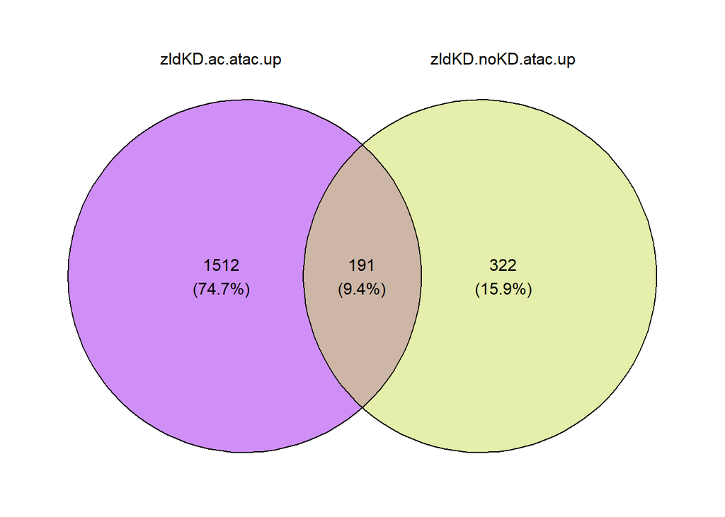

```r
#pdf("../zld.up.venn.pdf")
ggvenn(
  list(zldKD.ac.atac.up=res.zld.ac.atac.up$peak.name, zldKD.noKD.atac.up=res.zld.noKD.atac.up$peak.name),
  fill_color = c("purple", "#CD5"),
  stroke_size = 0.5, set_name_size = 4
  )
```

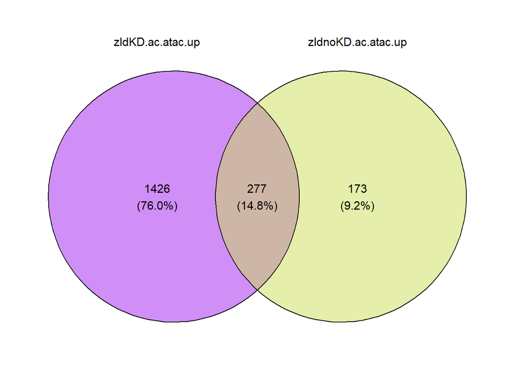

```r
ggvenn(
  list(zldKD.ac.atac.up=res.zld.ac.atac.up$peak.name, zldnoKD.ac.atac.up=res.zldnoKD.ac.atac.up$peak.name),
  fill_color = c("purple", "#CD5"),
  stroke_size = 0.5, set_name_size = 4
  )
```

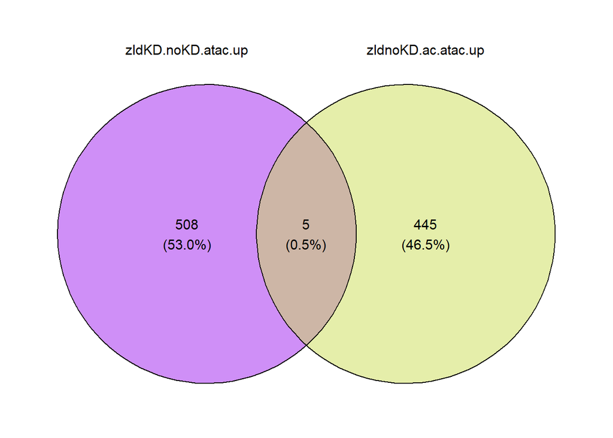

```r
ggvenn(
  list(zldKD.noKD.atac.up=res.zld.noKD.atac.up$peak.name, zldnoKD.ac.atac.up=res.zldnoKD.ac.atac.up$peak.name),
  fill_color = c("purple", "#CD5"),
  stroke_size = 0.5, set_name_size = 4
  )
```

```r
#dev.off()
```

```r
res.zld.ac.atac.down<-res.zld.ac.atac%>% filter(Change== "DOWN")
res.zld.noKD.atac.down<-res.zld.noKD.atac%>% filter(Change == "DOWN")
res.zldnoKD.ac.atac.down <-res.zldnoKD.ac.atac%>% filter(Change == "DOWN")
```

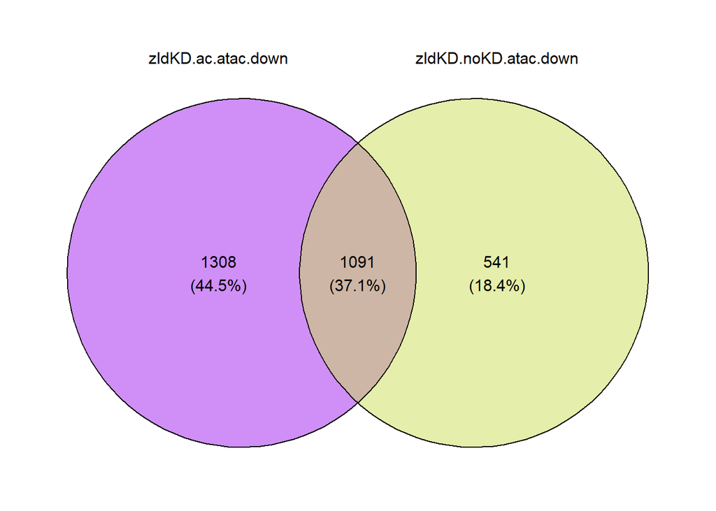

```r
#pdf("../zld.down.venn.pdf")
ggvenn(
  list(zldKD.ac.atac.down=res.zld.ac.atac.down$peak.name, zldKD.noKD.atac.down=res.zld.noKD.atac.down$peak.name),
  fill_color = c("purple", "#CD5"),
  stroke_size = 0.5, set_name_size = 4
  )
```

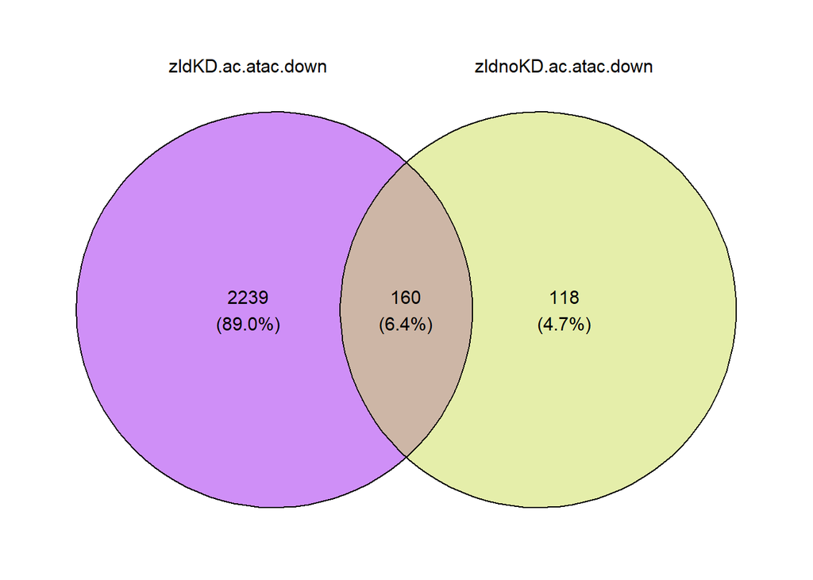

```r
ggvenn(
  list(zldKD.ac.atac.down=res.zld.ac.atac.down$peak.name, zldnoKD.ac.atac.down=res.zldnoKD.ac.atac.down$peak.name),
  fill_color = c("purple", "#CD5"),
  stroke_size = 0.5, set_name_size = 4
  )
```

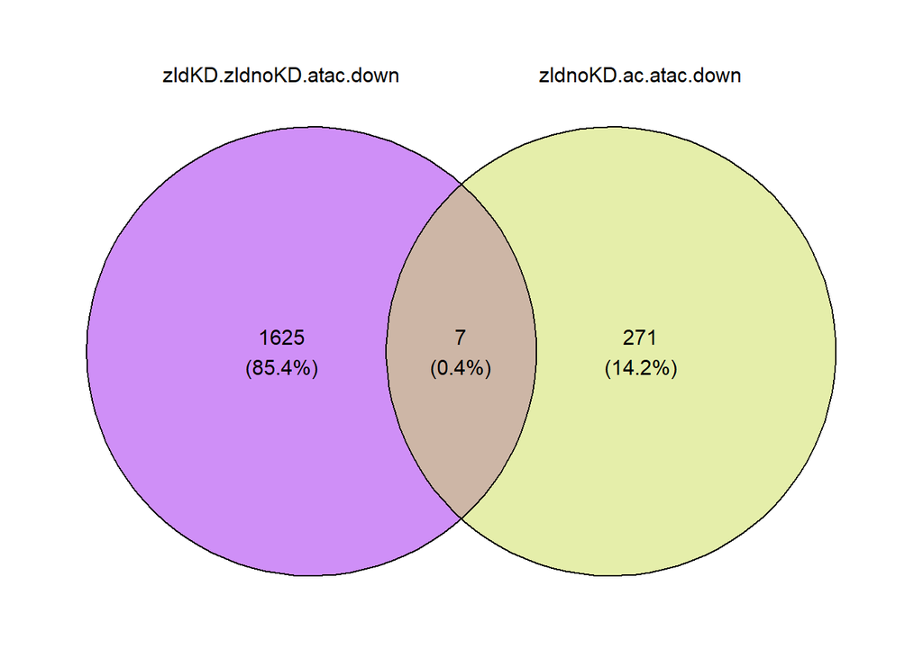

```r
ggvenn(
  list(zldKD.zldnoKD.atac.down=res.zld.noKD.atac.down$peak.name, zldnoKD.ac.atac.down=res.zldnoKD.ac.atac.down$peak.name),
  fill_color = c("purple", "#CD5"),
  stroke_size = 0.5, set_name_size = 4
  )
```

```r
#dev.off()
```

```r
up.overlap<-Reduce(intersect, list(res.zld.ac.atac.up$peak.name,res.zld.noKD.atac.up$peak.name))
res.zldnoKD.ac.atac[up.overlap,] %>%
  merge(x=.,y=genomic.feature.peaks, by = "peak.name",all.x = TRUE)  %>%
  merge(x=.,y=motif.table, by = "peak.name",all.x = TRUE) %>%
  #arrange(original.row) %>%
 mutate(has.zld.motif = if_else((zld.sites ==TRUE | zld.sites.rc == TRUE | zld.sites.2 == TRUE | zld.sites.rc.2),TRUE,FALSE)) %>%
  count(has.zld.motif) %>%
  mutate(percent = round((n / sum(n)) * 100,1)) %>%
  arrange(desc(percent))
```

```
##   has.zld.motif   n percent
## 1         FALSE 101    52.9
## 2          TRUE  90    47.1
```

```r
get.my.seqs(p = peaks.32157[names(peaks.32157) %in% up.overlap], dir = sequence.output.directory, name = "zldKDup.overlap.ac-daps.txt")
```

```r
down.overlap<-Reduce(intersect, list(res.zld.ac.atac.down$peak.name,res.zld.noKD.atac.down$peak.name))
res.zldnoKD.ac.atac[down.overlap,] %>%
  merge(x=.,y=genomic.feature.peaks, by = "peak.name",all.x = TRUE)  %>%
  merge(x=.,y=motif.table, by = "peak.name",all.x = TRUE) %>%
  #arrange(original.row) %>%
 mutate(has.zld.motif = if_else((zld.sites ==TRUE | zld.sites.rc == TRUE | zld.sites.2 == TRUE | zld.sites.rc.2),TRUE,FALSE)) %>%
  count(has.zld.motif) %>%
  mutate(percent = round((n / sum(n)) * 100,1)) %>%
  arrange(desc(percent))
```

```
##   has.zld.motif    n percent
## 1          TRUE 1018    93.3
## 2         FALSE   73     6.7
```

### 7. High-level observations about genes differentially expressed in (degs) Cal-zld

#### Gene expression profile by stages

Below is the number of DEGs upon Cal-zld KD.

```r
res.zldnoKD.ac.rna %>%
  count(Sig) %>%
  mutate(percent = round((n / sum(n)) * 100,1)) %>%
  arrange(desc(n))
```

```
##     Sig    n percent
## 1 FALSE 7056    90.2
## 2  TRUE  763     9.8
```

Below is the % of DEGs whose expression decreases or increases.

```r
res.zldnoKD.ac.rna %>%
  filter(.,Sig != "NA") %>%
  mutate(Change = case_when(
  Change == "UP" ~ "UP",
  Change == "DOWN" ~ "DOWN",
  Change == "NA" ~ "Not affected")) %>%
  count(Change) %>%
  mutate(percent = round((n / sum(n)) * 100,1)) %>%
  arrange(desc(n))
```

```
##         Change    n percent
## 1 Not affected 7056    90.2
## 2           UP  495     6.3
## 3         DOWN  268     3.4
```

Now we want to determine the maternal vs zygotic identify of Cal-zld DEGs.

First we need to identify genes whose expression is maternal, zygotic, maternal-zygotic or neither.

To do so we will create a count threshold for each gene in NC2/3 (~45 min old, before zygotic transcription, enriched in maternally deposited mRNAs) and syncytial embryos (NC11-Late NC14)

We will load WT RNA-seq timecourse data.

Sample order: 1-4 NC2/3/maternal, 5-8 NC11, 9-12 NC12, 13-16 NC13, 17-20 NC14, 21-24 LNC14

```r
load("../GRanges/wt-tc-rnaseq.GRanges.R")

head(wt.tc.rnaseq)
```

```
## GRangesList object of length 6:
## $wt.1.mat.RNA.TC1.23003FL.09.01.01
## GRanges object with 25866394 ranges and 0 metadata columns:
##                seqnames            ranges strand
##                   <Rle>         <IRanges>  <Rle>
##          [1] scaffold_1       41411-41563      +
##          [2] scaffold_1       48342-48465      +
##          [3] scaffold_1       48541-48623      +
##          [4] scaffold_1       48544-48656      +
##          [5] scaffold_1       48559-48757      +
##          ...        ...               ...    ...
##   [25866390] scaffold_7 51666660-51666877      +
##   [25866391] scaffold_7 51665953-51667259      -
##   [25866392] scaffold_7 51667142-51667229      +
##   [25866393] scaffold_7 51667142-51667229      +
##   [25866394] scaffold_7 51667153-51667249      -
##   -------
##   seqinfo: 6 sequences from ca6 genome
##
## ...
## <5 more elements>
```

Count overlaps of RNA-seq reads with transcripts.by.gene.

```r
genome(wt.tc.rnaseq) <- "ca6" # make sure the genome is specified
wt.counts.rna <- lapply(wt.tc.rnaseq, function(x) countOverlaps(transcripts.by.gene,x))
wt.counts.rna <- do.call("cbind",wt.counts.rna) # force the counts data into a table format where rows are genes and columns are samples

head(wt.counts.rna[,1:6])
```

```
##                        wt.1.mat.RNA.TC1.23003FL.09.01.01
## evm.TU.scaffold_1.10                                   0
## evm.TU.scaffold_1.100                                  0
## evm.TU.scaffold_1.1000                              4201
## evm.TU.scaffold_1.1001                              1862
## evm.TU.scaffold_1.1002                               340
## evm.TU.scaffold_1.1003                              7679
##                        wt.2.mat.RNA.TC1.23003FL.09.01.02
## evm.TU.scaffold_1.10                                   0
## evm.TU.scaffold_1.100                                  0
## evm.TU.scaffold_1.1000                              4176
## evm.TU.scaffold_1.1001                              1667
## evm.TU.scaffold_1.1002                               342
## evm.TU.scaffold_1.1003                              6691
##                        wt.3.mat.RNA.TC1.23003FL.09.01.03
## evm.TU.scaffold_1.10                                   0
## evm.TU.scaffold_1.100                                  0
## evm.TU.scaffold_1.1000                              4460
## evm.TU.scaffold_1.1001                              1475
## evm.TU.scaffold_1.1002                               341
## evm.TU.scaffold_1.1003                              6349
##                        wt.4.mat.RNA.TC1.23003FL.09.01.04
## evm.TU.scaffold_1.10                                   0
## evm.TU.scaffold_1.100                                  0
## evm.TU.scaffold_1.1000                              3374
## evm.TU.scaffold_1.1001                              1291
## evm.TU.scaffold_1.1002                               268
## evm.TU.scaffold_1.1003                              4508
##                        wt.1.NC11.RNA.TC1.23003FL.09.01.05
## evm.TU.scaffold_1.10                                    0
## evm.TU.scaffold_1.100                                   0
## evm.TU.scaffold_1.1000                               4792
## evm.TU.scaffold_1.1001                                758
## evm.TU.scaffold_1.1002                                509
## evm.TU.scaffold_1.1003                               7111
##                        wt.2.NC11.RNA.TC1.23003FL.09.01.06
## evm.TU.scaffold_1.10                                    0
## evm.TU.scaffold_1.100                                   0
## evm.TU.scaffold_1.1000                               5476
## evm.TU.scaffold_1.1001                                638
## evm.TU.scaffold_1.1002                                528
## evm.TU.scaffold_1.1003                               7585
```

Distribution of gene counts of maternal samples.

The low point is ~2^5. This distribution picks up after.

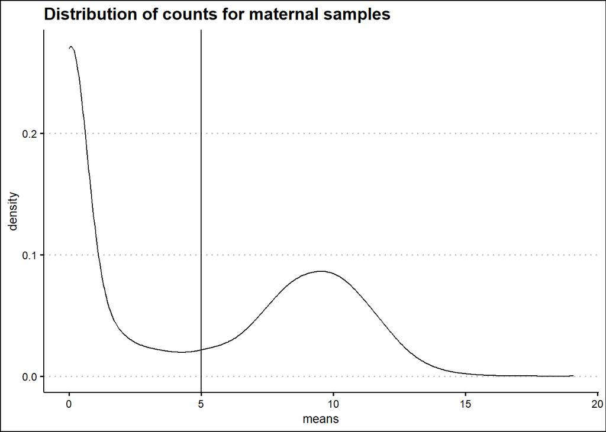

```r
data.frame(means = log2(rowMeans(wt.counts.rna[,1:4])+1)) %>%
  ggplot(aes(means)) +
  geom_density() +
  geom_vline(xintercept = 5) +
  theme_clean() +
  labs(title = 'Distribution of counts for maternal samples')
```

Distribution of gene counts of syncytial (zygotic) samples.

The low point is likewise around 2^5.

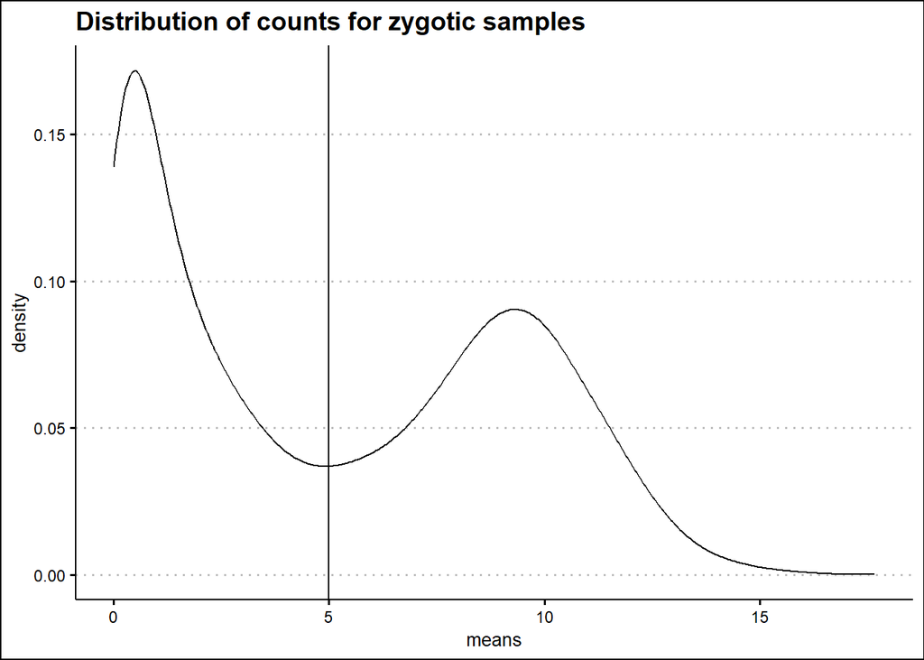

```r
data.frame(means = log2(rowMeans(wt.counts.rna[,5:24])+1)) %>%
  ggplot(aes(means)) +
  geom_density() +
  geom_vline(xintercept = 5) +
  theme_clean() +
  labs(title = 'Distribution of counts for zygotic samples')
```

Now we will identify genes expressed in maternal or zyotic stages based on the distributions above.

We will use the thresholds of 2^5.

*maternal* First create an index of the row positions. Then extract the row name corresponding to the gene name (rowname = gene name).

```r
mat.index <- which(rowMeans(wt.counts.rna[,1:4]) > 2^5)
#mat.index
mat.genes <- rownames(wt.counts.rna[mat.index,])
```

*zygotic* Repeat the process for zygotic genes.

```r
zyg.index <-  which(rowMeans(wt.counts.rna[,5:24]) > 2^5)

zyg.genes <- rownames(wt.counts.rna[zyg.index,])
```

Create a df summarizing the maternal-zygotic expression of a gene. Column, “gene.locus” will contain the gene name. Columns, “maternal” and “zygotic”, will be T/F indicating if the gene was expressed or not at the respective developmental stage. We will create a final column “MZ” indicating if the gene is strictly maternal, strictly zygotic, both maternal zygotic or neither.

```r
mz.df <- data.frame(gene.locus = rownames(wt.counts.rna))
```

```r
mz.df <- mz.df %>%
  mutate(maternal = gene.locus %in% mat.genes) %>%
  mutate(zygotic = gene.locus %in% zyg.genes) %>%
  mutate(MZ=case_when(
  maternal == TRUE & zygotic == TRUE ~  "maternal zygotic",
  maternal == FALSE & zygotic == FALSE ~  "neither",
  maternal == TRUE & zygotic == FALSE ~  "maternal",
  maternal == FALSE & zygotic == TRUE ~  "zygotic"))

mz.df %>% head()
```

```
##               gene.locus maternal zygotic               MZ
## 1   evm.TU.scaffold_1.10    FALSE   FALSE          neither
## 2  evm.TU.scaffold_1.100    FALSE   FALSE          neither
## 3 evm.TU.scaffold_1.1000     TRUE    TRUE maternal zygotic
## 4 evm.TU.scaffold_1.1001     TRUE    TRUE maternal zygotic
## 5 evm.TU.scaffold_1.1002     TRUE    TRUE maternal zygotic
## 6 evm.TU.scaffold_1.1003     TRUE    TRUE maternal zygotic
```

Below is the distribution of the MZ column.

```r
mz.df %>% count(.,MZ)
```

```
##                 MZ    n
## 1         maternal  227
## 2 maternal zygotic 6658
## 3          neither 7473
## 4          zygotic  691
```

```r
write.csv(mz.df, "../WT_timecourse/mz.df.csv")
```

#### Beeswarm plot for zldKD and control comparisons

Now returning to the Cal-Zld data..

Combine the Cal-zld RNA-seq DE results df (res.zldnoKD.ac.rna) with the MZ identity df (mz.df). Filter significant DEGs in Cal-zld RNAi embryos. Group by “Change” and count the “MZ” identity column.

Below we see the % of DEGs that fall into one of the fourth MZ classifications segmented by change.

```r
mz.df<-read.csv("../WT_timecourse/mz.df.csv")
res.zldnoKD.ac.rna %>%
 merge(x = ., y = mz.df, by.x = "gene.locus", by.y = "gene.locus", all.x = TRUE) %>%
  filter(., Sig == TRUE) %>%
  group_by(Change) %>%
  count(MZ)
```

```
## # A tibble: 8 × 3
## # Groups:   Change [2]
##   Change MZ                   n
##   <chr>  <chr>            <int>
## 1 DOWN   maternal             4
## 2 DOWN   maternal zygotic   184
## 3 DOWN   neither             26
## 4 DOWN   zygotic             54
## 5 UP     maternal             4
## 6 UP     maternal zygotic   417
## 7 UP     neither             26
## 8 UP     zygotic             48
```

```r
res.zld.ac.rna%>%merge(x = ., y = mz.df, by.x = "gene.locus", by.y = "gene.locus", all.x = TRUE) %>%
  filter(., Sig == TRUE) %>%
  group_by(Change) %>%
  count(MZ)
```

```
## # A tibble: 8 × 3
## # Groups:   Change [2]
##   Change MZ                   n
##   <chr>  <chr>            <int>
## 1 DOWN   maternal             5
## 2 DOWN   maternal zygotic   593
## 3 DOWN   neither             58
## 4 DOWN   zygotic            209
## 5 UP     maternal            14
## 6 UP     maternal zygotic  1232
## 7 UP     neither             56
## 8 UP     zygotic             63
```

```r
res.zld.noKD.rna<-res.zld.noKD.rna %>%
 merge(x = ., y = mz.df, by.x = "gene.locus", by.y = "gene.locus", all.x = TRUE)

res.zld.noKD.rna %>%
  filter(., Sig == TRUE) %>%
  group_by(Change) %>%
  count(MZ)
```

```
## # A tibble: 8 × 3
## # Groups:   Change [2]
##   Change MZ                   n
##   <chr>  <chr>            <int>
## 1 DOWN   maternal             1
## 2 DOWN   maternal zygotic   164
## 3 DOWN   neither             32
## 4 DOWN   zygotic            124
## 5 UP     maternal             1
## 6 UP     maternal zygotic   286
## 7 UP     neither              7
## 8 UP     zygotic              9
```

```r
pdf(file = "../Plots/zld_zkdnoKD-deg-MZ-beeswarm_all.pdf", width = 8,height = 8)

res.zld.noKD.rna %>%
  filter((Sig==TRUE & MZ != "neither") ) %>%
  #filter(Sig==TRUE) %>%
   group_by(MZ) %>%
  ggplot(aes(x = log2FoldChange, y = MZ, color=Change, shape=MZ)) +
  scale_colour_manual(values = c("DOWN" = 'Dark red', "UP" = "Dark blue")) +
    ggbeeswarm::geom_beeswarm(groupOnX = FALSE, cex = 0.5, priority = "density", alpha = 0.5) +
    geom_vline(xintercept = c(-1, 1), linetype = 'dashed') +
    xlim(-15,15) +
    labs(y = "Maternal Zygotic Classification", x = "LFC") +
  ggthemes::theme_clean() +
    theme(legend.position = "bottom")
dev.off()
```

WT vs ac

```r
res.WT.ac.rna<-res.WT.ac.rna %>%
 merge(x = ., y = mz.df, by.x = "gene.locus", by.y = "gene.locus", all.x = TRUE)

res.WT.ac.rna%>%
  filter(., Sig == TRUE) %>%
  group_by(Change) %>%
  count(MZ)
```

```
## # A tibble: 8 × 3
## # Groups:   Change [2]
##   Change MZ                   n
##   <chr>  <chr>            <int>
## 1 DOWN   maternal             1
## 2 DOWN   maternal zygotic   383
## 3 DOWN   neither             25
## 4 DOWN   zygotic             86
## 5 UP     maternal             9
## 6 UP     maternal zygotic   628
## 7 UP     neither             71
## 8 UP     zygotic             67
```

```r
pdf(file = "../Plots/WT_ac-deg-MZ-beeswarm_all.pdf", width = 8,height = 8)

res.WT.ac.rna%>%
  filter((Sig==TRUE & MZ != "neither"))%>%
  #filter(Sig==TRUE) %>%
   group_by(MZ) %>%
  ggplot(aes(x = log2FoldChange, y = MZ, color=Change, shape=MZ)) +
  scale_colour_manual(values = c("DOWN" = 'Dark red', "UP" = "Dark blue")) +
    ggbeeswarm::geom_beeswarm(groupOnX = FALSE, cex = 0.5, priority = "density", alpha = 0.5) +
    geom_vline(xintercept = c(-1, 1), linetype = 'dashed') +
    xlim(-15,15) +
    labs(y = "Maternal Zygotic Classification", x = "LFC") +
  ggthemes::theme_clean() +
    theme(legend.position = "bottom")
dev.off()
```

```r
res.zldnoKD.ac.rna<-res.zldnoKD.ac.rna %>%
 merge(x = ., y = mz.df, by.x = "gene.locus", by.y = "gene.locus", all.x = TRUE)

res.zldnoKD.ac.rna%>%
  filter(., Sig == TRUE) %>%
  group_by(Change) %>%
  count(MZ)
```

```
## # A tibble: 8 × 3
## # Groups:   Change [2]
##   Change MZ                   n
##   <chr>  <chr>            <int>
## 1 DOWN   maternal             4
## 2 DOWN   maternal zygotic   184
## 3 DOWN   neither             26
## 4 DOWN   zygotic             54
## 5 UP     maternal             4
## 6 UP     maternal zygotic   417
## 7 UP     neither             26
## 8 UP     zygotic             48
```

```r
pdf(file = "../Plots/zldnoKD_ac-deg-MZ-beeswarm_all.pdf", width = 8,height = 8)

res.zldnoKD.ac.rna%>%
  filter((Sig==TRUE & MZ !="neither")) %>%
  #filter(Sig==TRUE) %>%
   group_by(MZ) %>%
  ggplot(aes(x = log2FoldChange, y = MZ, color=Change, shape=MZ)) +
  scale_colour_manual(values = c("DOWN" = 'Dark red', "UP" = "Dark blue")) +
   ggbeeswarm::geom_beeswarm(groupOnX = FALSE, cex = 0.5, priority = "density", alpha = 0.5) +
    geom_vline(xintercept = c(-1, 1), linetype = 'dashed') +
    xlim(-15,15) +
    labs(y = "Maternal Zygotic Classification", x = "LFC") +
  ggthemes::theme_clean() +
    theme(legend.position = "bottom")
dev.off()
```

zldKD vs ac

```r
res.zld.ac.rna<-res.zld.ac.rna %>%
 merge(x = ., y = mz.df, by.x = "gene.locus", by.y = "gene.locus", all.x = TRUE)

res.zld.ac.rna%>%
  filter(., Sig == TRUE) %>%
  group_by(Change) %>%
  count(MZ)
```

```
## # A tibble: 8 × 3
## # Groups:   Change [2]
##   Change MZ                   n
##   <chr>  <chr>            <int>
## 1 DOWN   maternal             5
## 2 DOWN   maternal zygotic   593
## 3 DOWN   neither             58
## 4 DOWN   zygotic            209
## 5 UP     maternal            14
## 6 UP     maternal zygotic  1232
## 7 UP     neither             56
## 8 UP     zygotic             63
```

```r
pdf(file = "../Plots/zld_ac-deg-MZ-beeswarm_all.pdf", width = 8,height = 8)

res.zld.ac.rna%>%
  filter((Sig==TRUE & MZ !="neither")) %>%
  #filter(Sig==TRUE) %>%
   group_by(MZ) %>%
  ggplot(aes(x = log2FoldChange, y = MZ, color=Change, shape=MZ)) +
  scale_colour_manual(values = c("DOWN" = 'Dark red', "UP" = "Dark blue")) +
   ggbeeswarm::geom_beeswarm(groupOnX = FALSE, cex = 0.5, priority = "density", alpha = 0.5) +
    geom_vline(xintercept = c(-1, 1), linetype = 'dashed') +
    xlim(-15,15) +
    labs(y = "Maternal Zygotic Classification", x = "LFC") +
  ggthemes::theme_clean() +
    theme(legend.position = "bottom")
dev.off()
```